# Angewandte Statistik Bachelor of Science

Workshop 4: Vergleich von Mittelwerten

# Einführung

In diesem Workshop geht es um die praktische Anwendung von Hypothesentests zum Vergleich von Mittelwerten und um die Interpretation der Ergebnisse. Beim Vergleichen von Mittelwerten mit Hilfe von statistischen Test muss unter anderem berücksichtigt werden ob der Mittelwert einer Stichprobe mit einem Referenzwert oder ob die Mittelwerte von zwei Stichproben/Gruppen miteinander verglichen werden sollen. Weiter spielt es eine Rolle ob die Daten in letzterem Fall abhängig oder unabhängig sind. Allgemein muss berücksichtigt werden ob die jeweiligen Prüfgrössen die Voraussetzung der Normalverteilung erfüllen oder nicht. Figure 1 gibt eine Übersicht zum Vorgehen bei der Auswahl des passenden statistischen Testverfahrens.

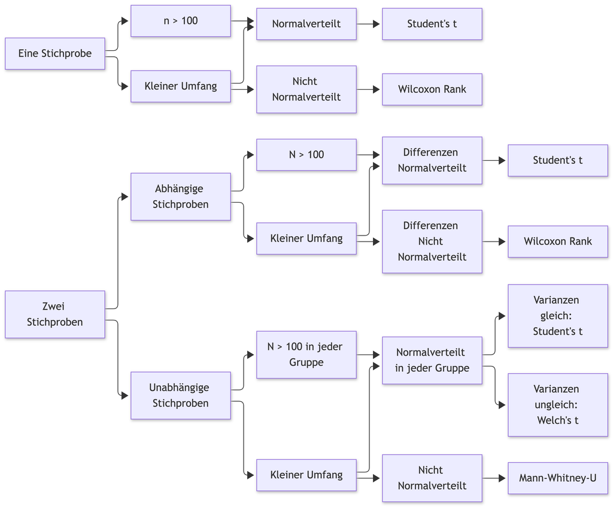

Figure 1: Übersicht zu statistischen Tests für den Vergleich von Mittelwerten einer oder zwei Stichproben. Die in jamovi verwendeten Begriffe Wilcoxon Rank Test und Mann-Whitney-U Test sind synonym zu den Bezeichnungen Wilcoxon Vorzeichen-Rang-Test respektive Wilcoxon Rangsummen-Test.

## Vergleich Stichprobe mit Referenzwert

Wir haben den Datensatz bmi_phy_w.csv mit BMI-Werten von Physiotherapie-Studentinnen vorliegen. Eine Musterlösung zum Nachvollziehen dieses Beispiels befindet sich in BSc_WS4_Intro_OneSample_BMI.omv.

Im Fall des Vergleichs eines Stichprobenmittelwerts mit einem Referenzwert möchten wir folgende Frage beantworten:

Unterscheidet sich der mittlere BMI einer Stichprobe von Physiotherapie-Studentinnen vom gesamtschweizerischen Durchschnitt von 23.7 kg / m<sup>2</sup>?

Diese Frage können wir mit dem Einstichproben t-Tests beantworten. Die Prüfgrösse ist der mittlere BMI. Die Hypothesen sind für den Einstichproben t-Test folgende ($\mu_0$: Referenzwert):

$$H_0: \mu = \mu_0$$

was bedeutet, dass der Populationsmittelwert **gleich ist** wie der Referenzwert.

$$H_A: \mu \neq \mu_0$$

was bedeutet, dass der Populationsmittelwert **nicht gleich ist** wie der Referenzwert.

Wir setzen das Signifikanzniveau für folgende Berechnungen auf $\alpha = 0.05$.

### Voraussetzungen

Es gelten folgende Voraussetzungen:

- Quantitativ-kontinuierliche Daten: gegeben durch den BMI, welcher sich aus gemessenem Körpergewicht und gemessener Körpergrösse berechnet.
- Unabhängige Beobachtungen: Es dürfen keine Personen mehrfach gemessen sein.
- Die Variable stammt aus normalverteilter Population:
  - Wir dürfen davon ausgehen wenn wir eine grosse Stichprobe mit $n > 100$ Beobachtungen haben oder wenn die BMI-Werte anhand des QQ-Plots als normalverteilt beurteilt werden.

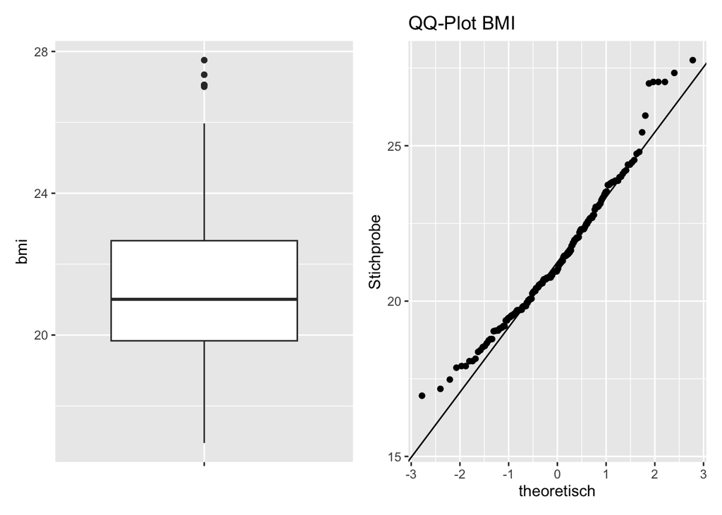

|  | Overall (N=183) |
| --- | --- |
| **bmi** |  |
| Mean (SD) | 21.4 (2.09) |
| Median [Min, Max] | 21.0 [17.0, 27.8] |

Aus der Deskriptivstatistik sehen wir, dass es im Datensatz 183 Beobachtungen gibt und wir eine grosse Stichprobe haben. Darum müssen wir die Normalverteilung hier nicht weiter beurteilen und führen zur Beantwortung der Fragen einen Einstichproben-T-Test durch.

### One Sample t-Test

In jamovi findet man den Einstichproben t-Test über *Analyses > T-Tests > One Sample T-Test*. Will man nun die Frage beantwortet ob sich der BMI Populationsmittelwert vom Referenzwert 23.7 kg/m2 unterscheidet muss man in jamovi bei **Test value = 23.7** eintragen.

One Sample T-Test

| One Sample T-Test | One Sample T-Test | One Sample T-Test Statistic | One Sample T-Test df | One Sample T-Test p | One Sample T-Test Mean difference | One Sample T-Test 95% Confidence Interval Lower | One Sample T-Test 95% Confidence Interval Upper |
| --- | --- | --- | --- | --- | --- | --- | --- |
| bmi | Student's t | -15.03 | 182.0 | < .001 | -2.323 | -2.628 | -2.018 |
| *Note.* Hₐ μ ≠ 23.7 |  |  |  |  |  |  |  |

Wir erhalten nun eine Tabelle mit den Resultaten des Einstichproben t-Tests, welcher die Differenz des Populationsmittelwertes geegüber der Referenz prüft. Dabei sind:

- Statistic: Die Teststatisik. Hier der t-Wert. Das heisst, die zum Standardfehler normierte Differenz zwischen geschätztem Populationsmittelwert und dem Referenzwert von 23.7 kg/m2.
- df: Die Anzahl Freiheitsgrade (engl. degrees of freedom). Im Falle des Einstichproben t-Test ist dies $n-1$.
- p: Der p-Wert. Das heisst, die Wahrscheinlichkeit das vorliegende Stichprobenergebnis oder ein extremeres unter der Nullhypothese zu beobachten.
- Mean Difference: Die Differenz zwischen geschätztem Populationsmittelwert und Referenzwert.
- CIlower: Untere Grenze des 95%-Vertrauensintervalls für die Differenz zwischen geschätztem Populationsmittelwert und Referenzwert.
- CIupper: Obere Grenze des 95%-Vertrauensintervalls zwischen geschätztem Populationsmittelwert und Referenzwert.

Möchte man nun noch das Vertrauensintervall für den geschätzten Populaitonsmittelwert berechnen, setzt man beim One Sample t-Test in jamovi den *Test value = 0* und man kriegt:

One Sample T-Test

| One Sample T-Test | One Sample T-Test | One Sample T-Test Statistic | One Sample T-Test df | One Sample T-Test p | One Sample T-Test Mean difference | One Sample T-Test 95% Confidence Interval Lower | One Sample T-Test 95% Confidence Interval Upper |
| --- | --- | --- | --- | --- | --- | --- | --- |
| bmi | Student's t | 138.3 | 182.0 | < .001 | 21.38 | 21.07 | 21.68 |
| *Note.* Hₐ μ ≠ 0 |  |  |  |  |  |  |  |

### Interpretation & Schlussfolgerung

Unterscheidet sich der mittlere BMI einer Stichprobe von Physiotherapie-Studentinnen vom gesamtschweizerischen Durchschnitt von 23.7 kg / m<sup>2</sup>?

- Der BMI von Physiotherapie-Studentinnen beträgt im Durchschnitt 21.4 kg/m2 [21.1; 21.7]. Er ist damit um durchschnittlich -2.3 kg/m2 [-2.6; -2.0] geringer, als der durchschnittliche BMI von 23.7 kg/m2 von Schweizer Frauen, t = 15.03, p < 0.001.
- Die Daten liefern Evidenz dafür, dass sich der durchschnittliche BMI von Physiotherapie-Studentinnen mit 21.4 kg/m2 [21.1; 21.7] signifikant vom durchschnittlichen BMI von 23.7 kg/m2 von Schweizer Frauen unterscheidet, t = 15.03, p < 0.001.

### Alternativen zum t-Test

Wir sind im Beispiel wegen des grossen Stichprobenumfangs davon ausgegangen, dass die Annahme der Normalverteilung der Variablen BMI plausibel ist. Ofmals hat man aber kleinere Umfänge und die Annahme der Normalverteilung kann fraglich sein.

Die Alternative, wenn nicht von Normalverteilung der Variablen ausgegangen werden kann, ist der **Wilcoxon Vorzeichen-Rang-Test** (jamovi *Wilcoxon rank*):

- Die Prüfgrösse ist der Median und nicht der Mittelwert wie beim Student’s t-Test. Er ersetzt die Daten mit deren Rängen.
- Es wird der Median mit einem Referenzmedian verglichen.
- Es ist ein sogenannt **nicht-parametrischer** Test: er macht keine Annahme bezüglich der exakten Verteilung => Normalverteilung ist nicht Voraussetzung.
- Die Daten sollten symmetrisch um den Median verteilt sein.

In jamovi findet man den Wilcoxon-Vorzeichen-Rangtest für eine Stichprobe am gleichen Ort wie vorhin unter *Analyses > T-Tests > One Sample T-Test*. Man wählt einfach zusätzlich die Option *Wilcoxon rank* an. Man kriegt dann im Output eine zusätzliche Zeile mit den Resultaten des Wilcoxon-Tests.

One Sample T-Test

| One Sample T-Test | One Sample T-Test | One Sample T-Test Statistic | One Sample T-Test df | One Sample T-Test p | One Sample T-Test Mean difference | One Sample T-Test 95% Confidence Interval Lower | One Sample T-Test 95% Confidence Interval Upper |
| --- | --- | --- | --- | --- | --- | --- | --- |
| bmi | Student's t | -15.03 | 182.0 | < .001 | -2.323 | -2.628 | -2.018 |
|  | Wilcoxon W | 1211 |  | < .001 | -2.439 | -2.743 | -2.124 |
| *Note.* Hₐ μ ≠ 23.7 |  |  |  |  |  |  |  |

- Die Teststatistik ist für den Wilcoxon-Test jetz nicht mehr der t-Wert, sondern eine Summe von Rängen. Auf Details wollen wir an dieser Stelle nicht eingehen. Wichtig ist zu erkennen, dass am Testentscheid bezüglich der Hypothesen nichts ändert. Das Ergebnis ist mit $p<0.001$ nach wie vor statistisch signifikant.
- Mean Difference: Das ist nun die Differenz vom Median BMI zum Referenzwert.

## Vergleich unabhängiger Gruppen

Als Beispiel für den Vergleich von Mittelwerten von unabhängigen Stichproben schauen wir uns den BMI im Vergleich zwischen männlichen und weiblichen Physiotherapie-Studierenden an. Dazu steht der Datensatz bmi_phy_45.csv zur Verfügung. Eine Musterlösung zum Nachvollziehen dieses Beispiels befindet sich in BSc_WS4_Intro_IndependentSamples_BMI.omv.

Wir wollen folgende Frage beantworten:

Unterscheidet sich der mittlere BMI zwischen Physiotherapie-Studentinnen und – Studenten?

Diese Frage können wir mit dem Zwweistichproben t-Test für unabhängige Stichproben beantworten. Die Stichproben (oft auch als Gruppen bezeichnet) sind dabei unabhängig weil die Werte in den Gruppen **von unterschiedlichen Personen** stammen. Man sagt auch, dass die Daten in diesem Fall unverbunden oder unabhängig sind.

Die Hypothesen lauten:

Nullhypothese

$$H_0: \mu_m = \mu_w$$

oder

$$H_0: \mu_m - \mu_w = 0$$

Alternativhypothese

$$H_A: \mu_m \neq \mu_w$$

oder

$$H_A: \mu_m - \mu_w \neq 0$$

Im Fall der Nullhypothese behauptet man, dass die Differenz der Populationsmittelwerte Null ist. Im Fall der Alternativhypothese behauptet man, dass die Differenz der Populationsmittelwerte nicht Null ist.

Wir setzen das Signifikanzniveau für folgende Berechnungen auf $\alpha = 0.05$.

### Voraussetzungen

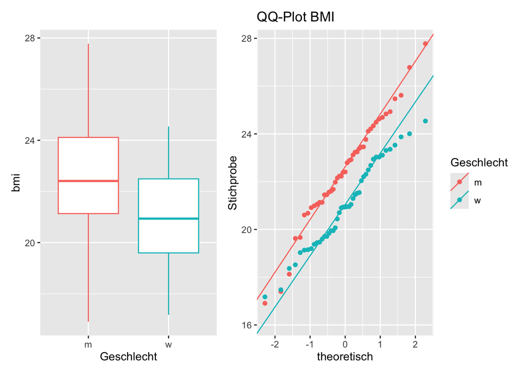

|  | m (N=45) | w (N=45) |
| --- | --- | --- |
| **bmi** |  |  |
| Mean (SD) | 22.5 (2.24) | 21.0 (1.82) |
| Median [Min, Max] | 22.4 [16.9, 27.8] | 20.9 [17.2, 24.5] |

Es gelten folgende Voraussetzungen:

- Quantitativ-kontinuierliche Daten: gegeben durch den BMI, welcher sich aus gemessenem Körpergewicht und gemessener Körpergrösse berechnet.
- Unabhängige Beobachtungen: Es dürfen keine Personen mehrfach gemessen sein. Das ist in diesem Beispiel gegeben.
- Die Daten sind **in beiden** Stichproben normalverteilt -> QQ-Plot
- Die Streuung der Daten ist in beiden Gruppen gleich -> Varianz, Standardabweichung, Boxplots

Normalverteilung

Aus der Deskriptivstatistk ist zu lesen, dass es in jeder Gruppe (m, w) je 45 Beobachtungen gibt. Dabei handelt es sich nicht um grosse Stichproben (Fachleute sind sich da einig; wir setzen die Grenze bei 100). Da es mehr als 30 Beobachtungen pro Gruppe sind, dürfen wir den QQ-Plot heranziehen um die Verteilung zu beurteilen. Bei den weiblichen Studierenden scheint es etwas mehr Abweichung von der Normalverteilung zu geben. Für die weitere Analyse nehmen wir den BMI in beiden Gruppen als normalverteilt an.

Streuungen

Die Standardabweichungen sind in beiden Gruppen ähnlich. Die Breite der Boxen in den Boxplots weisen ebenfalls auf eine ähnliche Streuen des BMI in beiden Gruppen hin.

Die Voraussetzungen von Normalverteilung und gleichen Streuungen nehmen wir als erfüllt an und können daher einen Student’s Zweistichproben t-Test durchführen.

### t-Test für unabhängige Stichproben

Independent Samples T-Test

| Independent Samples T-Test | Independent Samples T-Test | Independent Samples T-Test Statistic | Independent Samples T-Test df | Independent Samples T-Test p | Independent Samples T-Test Mean difference | Independent Samples T-Test SE difference | Independent Samples T-Test 95% Confidence Interval Lower | Independent Samples T-Test 95% Confidence Interval Upper |
| --- | --- | --- | --- | --- | --- | --- | --- | --- |
| bmi | Student's t | 3.581 | 88.00 | < .001 | 1.538 | 0.4295 | 0.6844 | 2.391 |
| *Note.* Hₐ μ <sub>m</sub> ≠ μ <sub>w</sub> |  |  |  |  |  |  |  |  |

Wir erhalten nun eine Tabelle mit den Resultaten des t-Tests für unabhängige Stichproben, welcher die Differenz zwischen den Stichprobenmittelwerten auf Unterschiedlichkeit von Null prüft. Dabei sind:

- Statistic: Die Teststatisik. Hier der t-Wert. Das heisst, die zum Standardfehler normierte Differenz der Gruppenmittelwerte.
- df: Die Anzahl Freiheitsgrade (engl. degrees of freedom). Im Fall des t-Test für unabhängige Stichproben $n-2$.
- p: Der p-Wert. Das heisst, die Wahrscheinlichkeit das vorliegende Stichprobenergebnis oder ein extremeres unter der Nullhypothese zu beobachten.
- Mean Difference: Die mittlere Differenz zwischen den Gruppenmittelwerten.
- SE Difference: Der Standardfehler für die mittlere Differenz.
- CIlower: Untere Grenze des 95%-Vertrauensintervalls für die Differenz zwischen den Gruppenmittelwerten.
- CIupper: Obere Grenze des 95%-Vertrauensintervalls für die Differenz zwischen den Gruppenmittelwerten.

### Alternative bei ungleichen Streuungen

Im vorliegenden Beispiel kamen wir zum Schluss, dass die Streuungen in den Gruppen ähnlich waren. Das ist aber nicht immer der Fall. Sollte es nicht der Fall sein, würde jamovi darauf hinweisen. In diesem Fall kommt der *Welch’s t-Test* zum Zug, welcher für ungleiche Varianzen korrigiert. Um diesen durchzuführen kann man in jamovi die entsprechende Option aktivieren und man bekommt eine zusätzliche Zeile Output:

Independent Samples T-Test

| Independent Samples T-Test | Independent Samples T-Test | Independent Samples T-Test Statistic | Independent Samples T-Test df | Independent Samples T-Test p | Independent Samples T-Test Mean difference | Independent Samples T-Test SE difference | Independent Samples T-Test 95% Confidence Interval Lower | Independent Samples T-Test 95% Confidence Interval Upper |
| --- | --- | --- | --- | --- | --- | --- | --- | --- |
| bmi | Student's t | 3.581 | 88.00 | < .001 | 1.538 | 0.4295 | 0.6844 | 2.391 |
|  | Welch's t | 3.581 | 84.50 | < .001 | 1.538 | 0.4295 | 0.6839 | 2.392 |
| *Note.* Hₐ μ <sub>m</sub> ≠ μ <sub>w</sub> |  |  |  |  |  |  |  |  |

Weil die Streuungen im vorliegenden Beispiel eben sehr ähnlich sind, ändern die Vertrauensintervalle nur geringfügig.

### Alternative bei nicht normalverteilten Daten

Falls es in mindestens einer der beiden Gruppen die Normalverteilung fraglich ist, kann der Mann-Whitney-U-Test (Wilcoxon Rangsummen-Test) für den Vergleich von unabhängigen Gruppen verwendet werden.

- Der Test beruht auf den Rängen und nicht den Daten selbst.
- Er ist nicht-parametrisch und macht keine Annahmen bezüglich der Verteilung.
- Er testet nicht dasselbe wie der t-Test:
  - $H_0$: $P(X>Y)=P(Y>X)$ d.h.: 50% Wahrscheinlichkeit, dass ein zufällig gezogener Wert aus Gruppe X grösser ist als ein zufällig gezogener Wert aus Gruppe Y.
  - $H_A$: $P(X>Y) \neq P(Y>X)$ d.h.: Die Wahrscheinlichkeit ist nicht 50%, dass ein zufällig gezogener Wert aus Gruppe X grösser ist als ein zufällig gezogener Wert aus Gruppe Y.
  - Nicht korrekt ist, dass der Test die Mediane der zwei Gruppen vergleicht.

In jamovi findet man den Test am selben Ort wie die anderen Test zum Vergleich von zwei unabhängigen Gruppen. Man aktiviert zusätzlich die Option *Mann-Whitney-U* und bekommt wiederum eine Zeile zusätzlichen Output:

Independent Samples T-Test

| Independent Samples T-Test | Independent Samples T-Test | Independent Samples T-Test Statistic | Independent Samples T-Test df | Independent Samples T-Test p | Independent Samples T-Test Mean difference | Independent Samples T-Test SE difference | Independent Samples T-Test 95% Confidence Interval Lower | Independent Samples T-Test 95% Confidence Interval Upper |
| --- | --- | --- | --- | --- | --- | --- | --- | --- |
| bmi | Student's t | 3.581 | 88.00 | < .001 | 1.538 | 0.4295 | 0.6844 | 2.391 |
|  | Welch's t | 3.581 | 84.50 | < .001 | 1.538 | 0.4295 | 0.6839 | 2.392 |
|  | Mann-Whitney U | 578.0 |  | < .001 | 1.610 |  | 0.7354 | 2.439 |
| *Note.* Hₐ μ <sub>m</sub> ≠ μ <sub>w</sub> |  |  |  |  |  |  |  |  |

Man kann feststellen, dass sich bezüglich Testentscheid nichts ändert (die Nullhypothese wird mit $p<0.001$ nach wie vor verworfen). Die mittlere Differenz wird geringfügig grösser geschätzt und das Vertrauensintervall ändert entsprechend auch ein wenig.

## Vergleich abhängiger Gruppen

Typische Beispiele für den Vergleich von abhängigen Daten sind Messwiederholungen. Dabei tauchen Beobachtungseinheiten mehrfach im Datensatz auf. Im Fall vom Messwiederholungen, wird ein Person zum Beispiel beim Eintritt in eine Studie gemessen und nach einer gewissen Interventionszeit wieder. Um den Prozess zu veranschaulichen analysieren wir die Schlafdauer ohne und mit Schlafmedikament. Dazu verenden wir die Daten schlafmittel.csv. Eine Musterlösung zum Nachvollziehen dieses Beispiels befindet sich in BSc_WS4_Intro_DependentSamples_Sleep.omv.

Wir wollen folgende Frage beantworten:

Unterscheidet sich die mittlere Schlafenszeit mit und ohne Schlafmedikament?

Diese Frage können wir mit dem Zweistichprobentest t-Test für abhängige Stichproben beantworten.

Die Hypothesen lauten:

Nullhypothese

$$H_0: \mu_{mit} = \mu_{ohne}$$

oder

$$H_0: \mu_{mit} - \mu_{ohne} = 0$$

Alternativhypothese

$$H_A: \mu_{mit} \neq \mu_{ohne}$$

oder

$$H_A: \mu_{mit} - \mu_{ohne} \neq 0$$

Im Fall der Nullhypothese behauptet man, dass die Differenz der Populationsmittelwerte Null ist. Im Fall der Alternativhypothese behauptet man, dass die Differenz der Populationsmittelwerte nicht Null ist.

Wir setzen das Signifikanzniveau für folgende Berechnungen auf $\alpha = 0.05$.

### Voraussetzungen

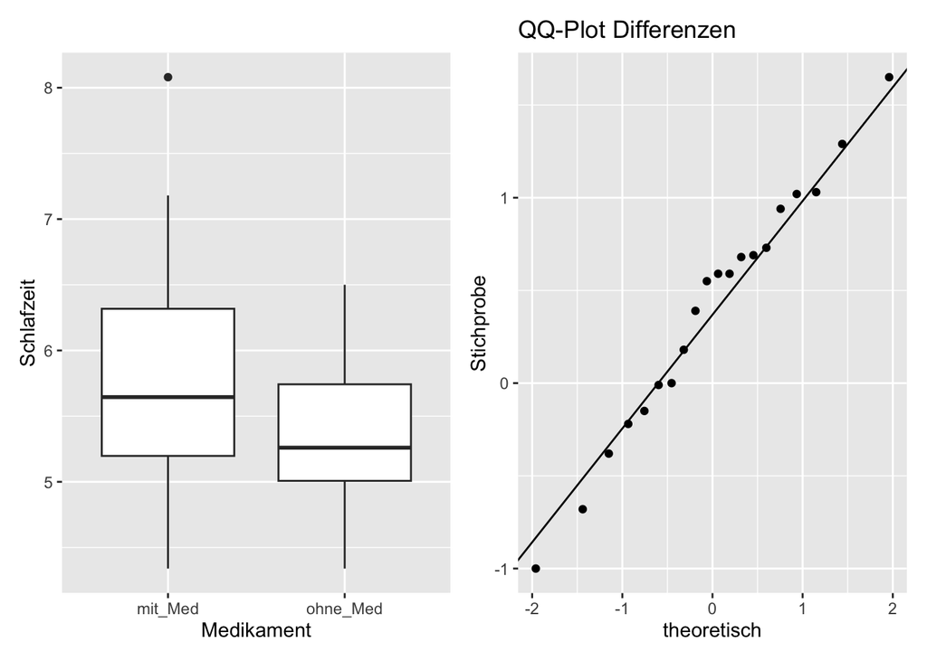

|  | mit_Med (N=20) | ohne_Med (N=20) |
| --- | --- | --- |
| **Schlafzeit** |  |  |
| Mean (SD) | 5.77 (0.953) | 5.38 (0.574) |
| Median [Min, Max] | 5.65 [4.34, 8.08] | 5.26 [4.34, 6.50] |

Das Vorgehen entspricht dem Einstichproben t-Test, jedoch mit dem Unteschied, dass die Prüfgrösse nicht die Variable selbst ist, sondern die **parweisen Differenzen**. Das führt zur Voraussetzung, dass die **paarweisen Differenzen in der Population normalverteilt sind**. Das scheint im vorliegenden Fall gegeben zu sein.

### t-Test für abhängige Stichproben

Paired Samples T-Test

| Paired Samples T-Test | Paired Samples T-Test | Paired Samples T-Test | Paired Samples T-Test statistic | Paired Samples T-Test df | Paired Samples T-Test p | Paired Samples T-Test Mean difference | Paired Samples T-Test SE difference | Paired Samples T-Test 95% Confidence Interval Lower | Paired Samples T-Test 95% Confidence Interval Upper |
| --- | --- | --- | --- | --- | --- | --- | --- | --- | --- |
| mit_Med | ohne_Med | Student's t | 2.624 | 19.00 | .017 | 0.3945 | 0.1504 | 0.07979 | 0.7092 |
| *Note.* Hₐ μ <sub>Measure 1 - Measure 2</sub> ≠ 0 |  |  |  |  |  |  |  |  |  |

Wir erhalten nun eine Tabelle mit den Resultaten des t-Tests für abhängige Stichproben, welcher die mittlere Differenz zwischen den Stichprobenmittelwerten auf Unterschiedlichkeit von Null prüft. Dabei sind:

- Statistic: Die Teststatisik. Hier der t-Wert. Das heisst, die zum Standardfehler normierte Differenz der Gruppenmittelwerte.
- df: Die Anzahl Freiheitsgrade (engl. degrees of freedom). Im Fall des t-Test für abhängige Stichproben $n-1$.
- p: Der p-Wert. Das heisst, die Wahrscheinlichkeit das vorliegende Stichprobenergebnis oder ein extremeres unter der Nullhypothese zu beobachten.
- Mean Difference: Die mittlere Differenz zwischen den Gruppenmittelwerten.
- SE Difference: Der Standardfehler für die mittlere Differenz.
- CIlower: Untere Grenze des 95%-Vertrauensintervalls für die Differenz zwischen den Gruppenmittelwerten.
- CIupper: Obere Grenze des 95%-Vertrauensintervalls für die Differenz zwischen den Gruppenmittelwerten.

### Interpretation und Schlussfolgerung

Unterscheidet sich die mittlere Schlafenszeit mit und ohne Schlafmedikament?

- Im Mittel ist die Schlafdauer mit Medikament im Vergleich zu ohne Medikament um 0.4 [0.08, 0.71] Stunden erhöht. t = 2.624, p = 0.017.
- Die Daten liefern Evidenz, dass die Schlafdauer im Mittel mit Medikament signifikant erhöht ist.

### Alternative bei nicht normalverteilten Differenzen

Wer aufmerksam war, hat bemerkt, dass wir mit den vorherigen Berechnungen die für uns geltende Regel verletzt haben, QQ-Plots nur ab einem Umfang von n = 30 zur Beurteilung der Verteilung zu interpretieren. Wir haben nur 20 paarweise Differenzen und müssten eigentlich davon ausgehen, dass wir damit die Verteilung der Differenzen in der Population nicht kennen. Auch für den Vergleich von Mittelwerten bei abhängigen Stichproben, gibt es, wie schon beim Einstichproben t-Tests, den Wilcoxon-Vorzeichen-Rang-Test (jamovi *Wilcoxon rank*) der in diesem Fall verwendet werden kann.

Paired Samples T-Test

| Paired Samples T-Test | Paired Samples T-Test | Paired Samples T-Test | Paired Samples T-Test statistic | Paired Samples T-Test df | Paired Samples T-Test p | Paired Samples T-Test Mean difference | Paired Samples T-Test SE difference | Paired Samples T-Test 95% Confidence Interval Lower | Paired Samples T-Test 95% Confidence Interval Upper |
| --- | --- | --- | --- | --- | --- | --- | --- | --- | --- |
| mit_Med | ohne_Med | Student's t | 2.624 | 19.00 | .017 | 0.3945 | 0.1504 | 0.07979 | 0.7092 |
|  |  | Wilcoxon W | 152.5<sup>a</sup> |  | .022 | 0.4500 | 0.1504 | 0.08503 | 0.7850 |
| *Note.* Hₐ μ <sub>Measure 1 - Measure 2</sub> ≠ 0 |  |  |  |  |  |  |  |  |  |
| <sup>a</sup> 1 pair(s) of values were tied |  |  |  |  |  |  |  |  |  |

Der p-Wert fällt mit dem Wilcoxon Rank Test etwas höher aus. Das Testergebnis bleibt jedoch statistisch signifikant. Die mittlere Differenz in der Schlafenszeit mit im Verleich zu ohne Medikament wird mit 0.45 h etwas grösser geschätzt.

# Aufgabe 1

**Aufgabe**

*Diese Übung machen wir von Hand, um das Prinzip zu verstehen.*

Eine Kaffeekette betreibt eine Filiale in Basel und eine Filiale in Bern. Die Berner Kolleginnen erzählen, dass sie mehr Caffè Latte (mittlere Grösse) in Bern als in Basel für das gleiche Geld erhalten. Sie können das nicht glauben und wollen der Sache auf den Grund gehen. Ihre Frage ist: Unterscheiden sich die Kaffeemengen an den Standorten Basel und Bern?

Als erstes sammeln Sie Daten: Sie kaufen an beiden Standorten 20 Becher Caffè Latte mittlerer Grösse. Sie messen jeweils die Mengen in ml. Ihre Auswertung kommt zu folgendem Ergebnis:

| Ort | n | m | s |
| --- | --- | --- | --- |
| Bern | 20 | 311.7 | 22.8 |
| Basel | 20 | 301.9 | 8.4 |

1. Formulieren Sie ihre Hypothese.
2. Berechnen sie die Vertrauensintervalle für die Kaffeemengen von Bern und Basel
3. Berechnen sie den t-Wert für den Mittelwertsvergleich.
4. Formulieren Sie ihr Resultat in ein bis zwei Sätzen.

**Hinweise:**

- Wir legen das Signifikanzniveau auf $\alpha = .05$ fest.
- Das Vorgehen ist vergleichbar mit den Übungen zu den Einstichproben-Tests. Allerdings haben Sie jetzt zwei Mittelwerte und zwei Standardabweichungen. Für die Berechnung von $SE$ müssen sie deshalb aus diesen beiden Standardabweichungen den gemeinsamen Standardfehler $SE_{pooled}$ berechnen nach der (etwas vereinfachten) Formel:

$$SE_{pooled} = \sqrt{\frac{s_{Bern}^2}{n_{Bern}} + \frac{s_{Basel}^2}{n_{Basel}}}$$

- Die Berechnung des t-Werts erfolgt nach der Formel

$$t = \frac{\bar{x}_{Basel} - \bar{x}_{Bern}}{SE_{pooled}}$$

- Die Anzahl Freiheitsgrade $df$ ist

$$df = n_1 + n_2 - 2 = n_{Bern} + n_{Basel} - 2$$

**Lösung**

1. Formulieren Sie ihre Hypothese.
- $H_0$ : Die Kaffeemengen von Bern und Basel unterscheiden sich nicht. $\mu_{Basel} = \mu_{Bern}$.
- $H_A$ : Die Kaffeemengen von Bern und Basel unterscheiden sich. $\mu_{Basel} \neq \mu_{Bern}$.
2. Berechnen sie die Vertrauensintervalle für die Kaffeemengen von Bern und Basel.
- *Wenn Sie die Vertrauensintervalle nicht von Hand rechnen wollen, können Sie diesen Code kopieren und in jamovi: Rj-Editor eingeben.*

```r
## Code für Rj-Editor

# Kennzahlen in Variablen erfassen
n <- 20            # beide Stichprobenumfänge betragen n = 20
m_Bern <- 311.7    # durchschnittliche Kaffeemenge in Bern
s_Bern <- 22.8     # Standardabweichung in Bern
m_Basel <- 301.9   # durchschnittliche Kaffeemenge in Basel
s_Basel <- 8.4     # Standardabweichung in Basel

# 95%-CI für Bern berechnen
se_Bern <- s_Bern/sqrt(n)               # SE für Bern
ci_Bern <- m_Bern + c(-2, 2) * se_Bern  # Grenzen für 95%-CI
ci_Bern <- round(ci_Bern, 2)            # 95%-CI auf zwei Stellen runden

# CI für Basel
se_Basel <- s_Basel/sqrt(n)                # SE für Basel
ci_Basel <- m_Basel + c(-2, 2) * se_Basel  # Grenzen für 95%-CI Basel
ci_Basel <- round(ci_Basel, 2)             # 95%-CI auf zwei Stellen runden

# 95%-CIs anzeigen
ci_Basel
```

```
[1] 298.14 305.66
```

```r
ci_Bern
```

```
[1] 301.5 321.9
```

In Bern beinhaltet ein Becher Kaffee im Durchschnitt 311.7 [301.5, 321.9] ml, in Basel im Durchschnitt 301.9 [298.1, 305.7] ml. Mit Blick auf die Mittelwerte scheint die Aussage ihrer Berner Kollegin zu stimmen. Wenn wir allerdings die Vertrauensintervalle betrachten, sehen wir, dass sich diese überschneiden. Daher besteht keine Evidenz dafür, dass die Kaffeemengen in Bern und Basel unterschiedlich sind und wir können die $H_0$ nicht verwerfen.

3. Berechnen sie den t-Wert für den Mittelwertsvergleich.

```r
# gemeinsamen Standardfehler berechnen (vereinfacht)
se_pooled <- sqrt((s_Bern^2/n) + (s_Basel^2/n))
se_pooled  # se_pooled anzeigen
```

```
[1] 5.433231
```

```r
# t-Wert berechnen
t_Wert <- (m_Basel - m_Bern)/se_pooled
t_Wert     # t_Wert anzeigen
```

```
[1] -1.803715
```

Der t-Wert für die Differenz der Kaffeemengen beträgt -1.804. Damit ist der Wert kleiner als +2/-2 Standardfehler und liegt im Nicht-Verwerfungsbereich für die $H_0$.

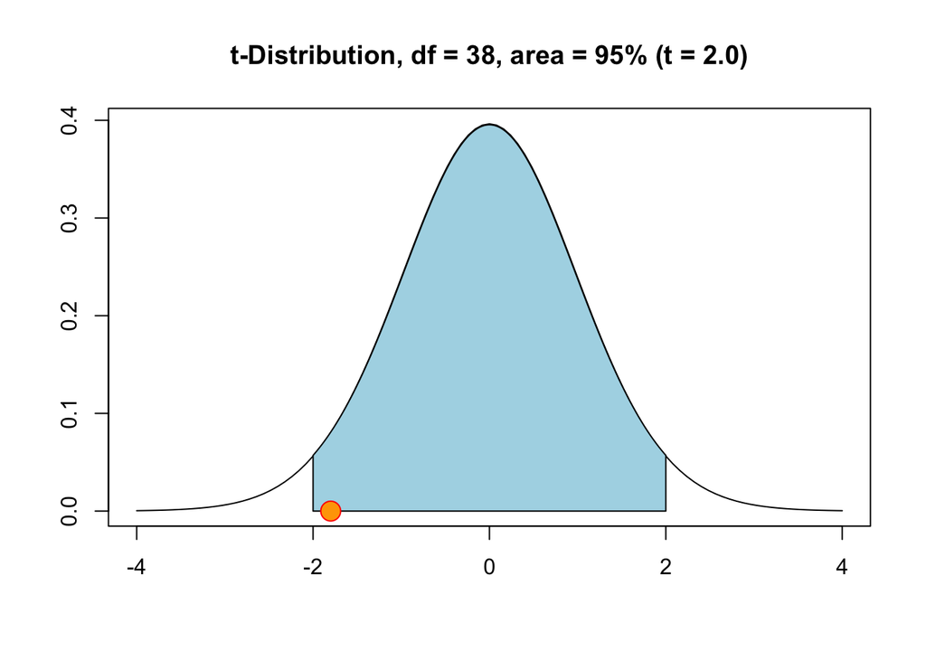

```r
# p-Wert für 2-seitige Hypothese berechnen
p_value <- 2 * pt(t_Wert, df = 38)
p_value
```

```
[1] 0.0792084
```

Der p-Wert ist mit 0.079 > 0.05. Wir haben keine Evidenz dafür, dass sich die Kaffeemengen in Bern und Basel signifikant unterscheiden und verwerfen $H_0$ nicht.

### 4. Formulieren Sie ihr Resultat in ein bis zwei Sätzen.

- Die durchschnittliche Kaffeemenge in der Filiale in Bern (311.7 [301.5, 321.9] ml) und in der Filiale in Basel (301.9 [298.1, 305.7] ml) unterscheiden sich nicht, t = -1.804, df = 38, p = 0.079.

# Aufgabe 2

Laden Sie die Datei caffe.csv in **jamovi**. **jamovi** erkennt die Datentypen automatisch korrekt.

Codebook: Der Datensatz umfasst zwei Variablen

| Variable | Beschreibung |
| --- | --- |
| Ort | Ort der Datenerhebung: Bern, Basel |
| Menge | Kaffeemenge in ml |

**Aufgabe**

0. Laden Sie den Datensatz in jamovi.
1. Formulieren Sie ihre Hypothese.
2. Beschreiben Sie die Daten deskriptiv. Erstellen Sie ein Boxplot für den Vergleich der Kaffeemengen in Bern und Basel.
3. Wählen Sie den richtigen t-Test aus (gemäss der Entscheidungskriterien müssten wir hier einen Man-Whitney-U-Test wählen, da n < 30, wir wählen aber den t-Test um das Ergebnis mit der Übung 1 zu vergleichen). Erstellen Sie auch eine Grafik für den Vergleich der 95%-Vertrauensintervalle.
4. Kopieren Sie den jamovi-Output in ein Word-Dokument und beschriften Sie die Tabellen und Grafiken so, dass sie selbsterklärend sind. Formulieren Sie ihr Resultat in ein bis zwei Sätzen.

**Lösung**

jamovi Lösung: BSc_WS4_Vergleich-MW-Ex2.omv

### 1. Formulieren Sie ihre Hypothese.

- $H_0$ : Die Kaffeemengen von Bern und Basel unterscheiden sich nicht. $\mu_{Basel} = \mu_{Bern}$.
- $H_A$ : Die Kaffeemengen von Bern und Basel unterscheiden sich. $\mu_{Basel} \neq \mu_{Bern}$.

### 2. Beschreiben Sie die Daten deskriptiv und erstellen Sie ein Boxplot für den Vergleich der Kaffeemengen in Bern und Basel.

Descriptives

| Descriptives | Descriptives Ort | Descriptives Menge |
| --- | --- | --- |
| N | Basel | 20 |
|  | Bern | 20 |
| Missing | Basel | 0 |
|  | Bern | 0 |
| Mean | Basel | 301.9 |
|  | Bern | 311.7 |
| Std. error mean | Basel | 1.887 |
|  | Bern | 5.101 |
| Median | Basel | 302.8 |
|  | Bern | 313.4 |
| Standard deviation | Basel | 8.438 |
|  | Bern | 22.81 |
| Minimum | Basel | 281.9 |
|  | Bern | 276.3 |
| Maximum | Basel | 317.6 |
|  | Bern | 349.8 |

Plots

Menge

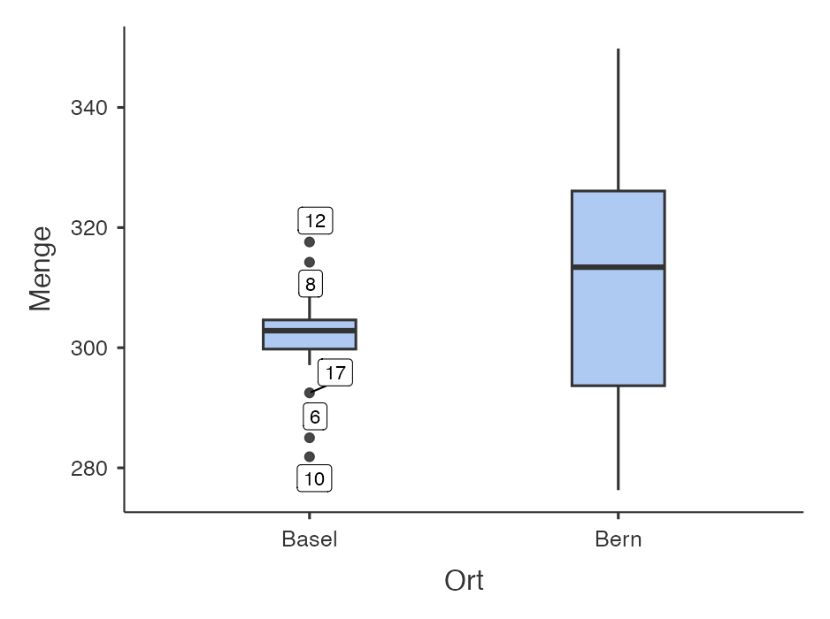

Der korrekt beschriftete Plot könnte etwa so aussehen:

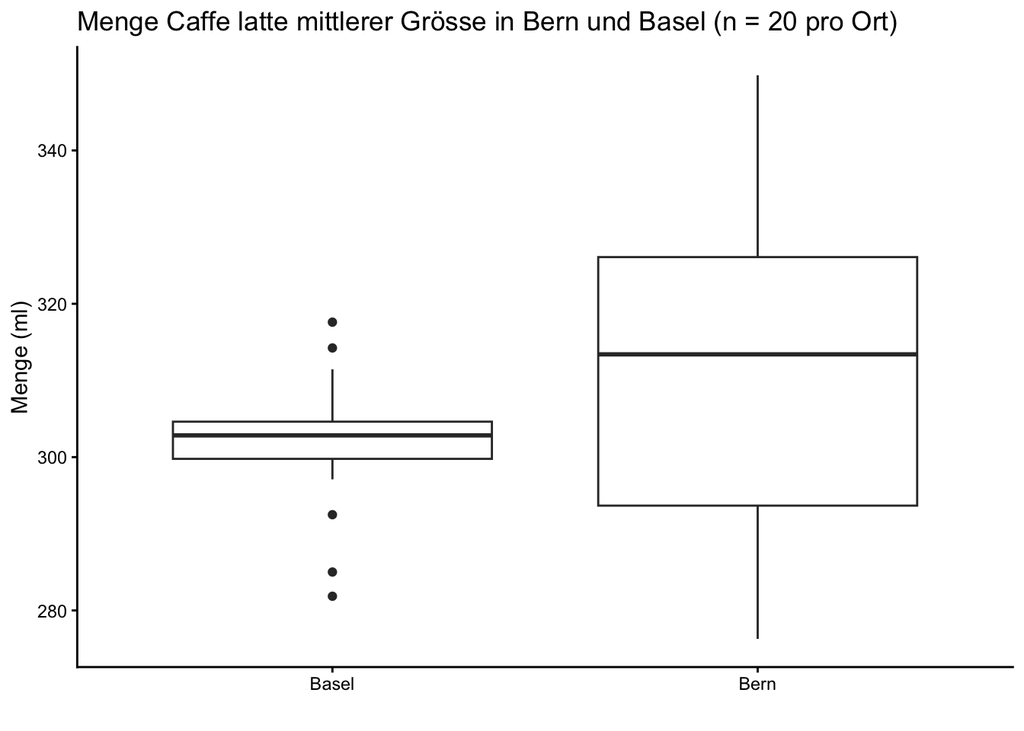

### 3. Wählen Sie den richtigen $t$-Test aus. Erstellen Sie auch eine Grafik für den Vergleich der 95%-Vertrauensintervalle.

- Es handelt sich um unabhängige Daten, daher wählen wir den *independent samples t-test*.
- Wählen sie den *Student’s Test* und unter *Additional Statistics > Descriptive plots*.
- Gegenüber der Berechnung von Hand ergeben sich geringfügige Rundungsfehler.

Independent Samples T-Test

| Independent Samples T-Test | Independent Samples T-Test | Independent Samples T-Test Statistic | Independent Samples T-Test df | Independent Samples T-Test p |
| --- | --- | --- | --- | --- |
| Menge | Student's t | -1.798<sup>a</sup> | 38.00 | .080 |
| *Note.* Hₐ μ <sub>Basel</sub> ≠ μ <sub>Bern</sub> |  |  |  |  |
| <sup>a</sup> Levene's test is significant (p < .05), suggesting a violation of the assumption of equal variances |  |  |  |  |

Plots

Menge

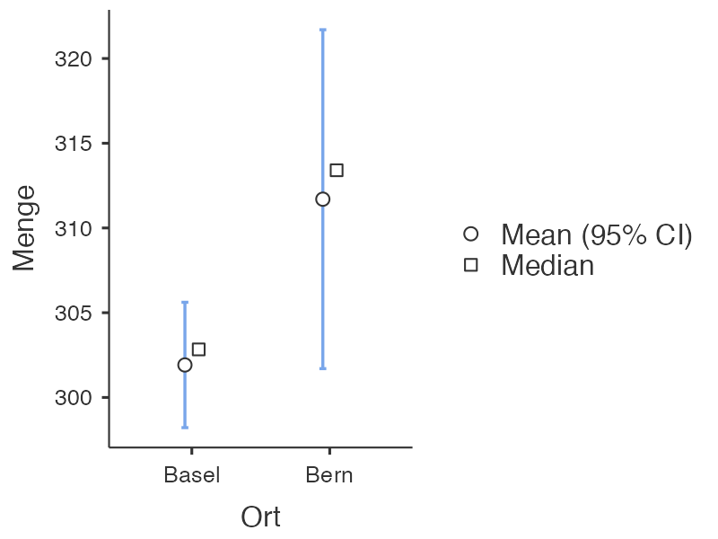

# Aufgabe 3

Arbeiten Sie mit dem Datensatz physio.csv.

**Aufgabe**

Untersuchen Sie, ob sich Studentinnen und Studenten in ihrer Körpergrösse unterscheiden.

0. Laden Sie den Datensatz `physio.csv` in jamovi.
1. Formulieren Sie ihre Hypothesen.
2. Beschreiben Sie die Daten deskriptiv. Erstellen Sie ein Boxplot für den Vergleich der Körpergrössen von Studentinnen und Studenten.
3. Prüfen Sie die Testvoraussetzungen und wählen Sie einen statistischen Test. Erstellen Sie auch eine Grafik für den Vergleich der 95%-Vertrauensintervalle.
4. Kopieren Sie den jamovi-Output in ein Word-Dokument und beschriften Sie die Tabellen und Grafiken so, dass sie selbsterklärend sind. Formulieren Sie ihr Resultat.

**Lösung**

jamovi Lösung: BSc_WS4_Vergleich-MW-Ex3.omv

### 1. Formulieren Sie ihre Hypothese.

- $H_0$ : Die Körpergrössen von Studentinnen (w) und Studenten (m) unterscheiden sich nicht. $\mu_{w} = \mu_{m}$.
- $H_A$ : Die Körpergrössen von Studentinnen (w) und Studenten (m) unterscheiden sich. $\mu_{w} \neq \mu_{m}$.

### 2. Beschreiben Sie die Daten deskriptiv. Erstellen Sie ein Boxplot für den Vergleich der Körpergrössen von Studentinnen und Studenten.

Descriptives

| Descriptives | Descriptives Geschlecht | Descriptives Groesse |
| --- | --- | --- |
| N | m | 45 |
|  | w | 183 |
| Missing | m | 0 |
|  | w | 0 |
| Mean | m | 179.9 |
|  | w | 166.9 |
| Median | m | 180.0 |
|  | w | 167.0 |
| Standard deviation | m | 6.387 |
|  | w | 5.664 |
| Minimum | m | 169.0 |
|  | w | 148.0 |
| Maximum | m | 198.0 |
|  | w | 183.0 |

Plots

Groesse

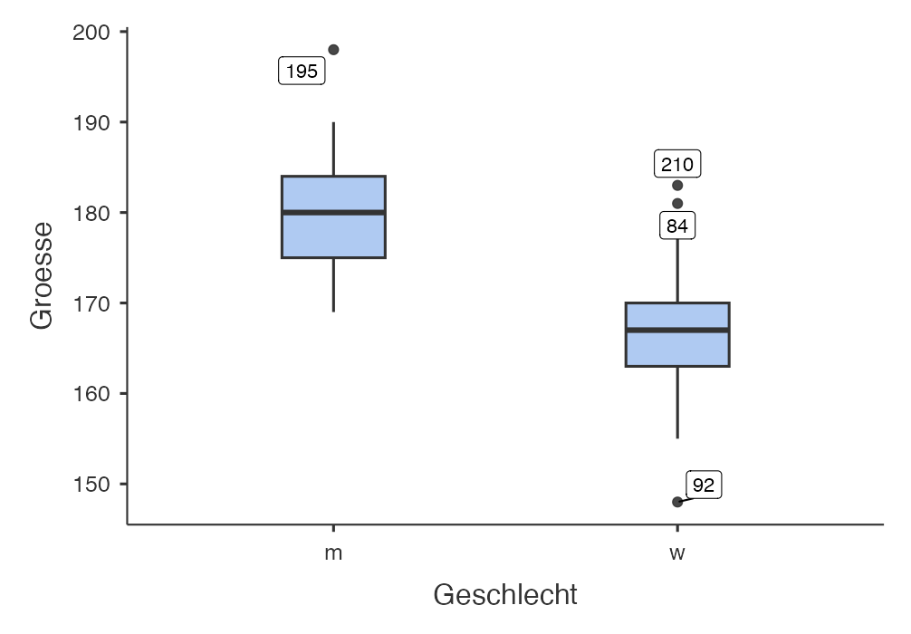

### 3. Prüfen Sie die Testvoraussetzungen und wählen Sie einen statistischen Test. Erstellen Sie auch eine Grafik für den Vergleich der 95%-Vertrauensintervalle.

Independent Samples T-Test

| Independent Samples T-Test | Independent Samples T-Test | Independent Samples T-Test Statistic | Independent Samples T-Test df | Independent Samples T-Test p | Independent Samples T-Test Mean difference | Independent Samples T-Test SE difference | Independent Samples T-Test 95% Confidence Interval Lower | Independent Samples T-Test 95% Confidence Interval Upper |
| --- | --- | --- | --- | --- | --- | --- | --- | --- |
| Groesse | Student's t | 13.38 | 226.0 | < .001 | 12.94 | 0.9671 | 11.04 | 14.85 |
|  | Mann-Whitney U | 486.5 |  | < .001 | 13.00 |  | 11.00 | 15.00 |
| *Note.* Hₐ μ <sub>m</sub> ≠ μ <sub>w</sub> |  |  |  |  |  |  |  |  |

Plots

Groesse

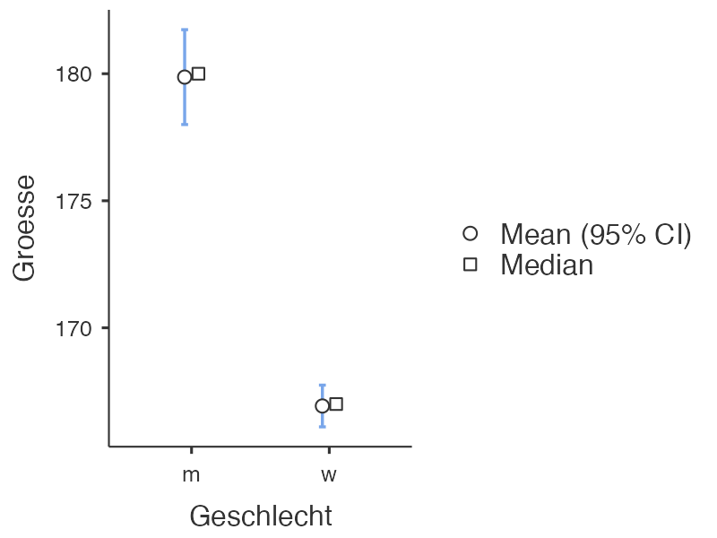

Output lesen und verstehen:

#### Student’s t

- Statistic = t-Wert = t = 13.38
- df = degrees of freedom = $n_w + n_m - 2$ = 228 - 2 = 226
- p = p-Wert < .001
- Mean difference = $\mu_m - \mu_w$ = 12.94
- SE difference = Standardfehler für die Differenz der Mittelwerte = .9671
- Lower = Untere Grenze des 95%-CI für die Differenz der Mittelwerte = 11.04
- Upper = Obere Grenze des 95%-CI für die Differenz der Mittelwerte = 14.85

#### Grafik 95% CI

- zeigt die Vertrauensintervalle für $\mu_m$ und $\mu_w$.
- Die Vertrauensintervalle überschneiden sich nicht.
- Zusatzfrage: Warum ist das Vertrauensintervall für $\mu_w$ schmaler als für $\mu_m$?
- Mit diesen Resulten besteht Evidenz dafür, dass sich Studentinnen und Studenten in der druchschnittlichen Körpergrösse unterscheiden. Da p < .05 ist, verwerfen Sie $H_0$ zugunsten von $H_A$.

#### 4. Kopieren Sie den jamovi-Output in ein Word-Dokument und beschriften Sie die Tabellen und Grafiken so, dass sie selbsterklärend sind. Formulieren Sie ihr Resultat.

- Geprüft wurde die Frage, ob sich Physiotherapie-Studentinnen und -Studenten in ihrer Körpergrösse unterscheiden. In Stichproben aus den Studienjahrgängen PHY13 - PHY17 ($n_w$ = 183, $n_m$ = 45) wurde die Körpergrösse gemessen. Studenten sind im Durchschnitt um 12.94 [11.04, 14.85] cm grösser als Studentinnen, $t$ = 13.38, $df$ = 226, $p$ < .001.
- Antwort auf die Zusatzfrage unter 3: Je grösser der Stichprobenumfang, desto kleiner wird $SE = \frac{s}{\sqrt{n}}$, desto schmaler das 95%-Konfidenzintervall.

# Aufgabe 4

Ein Gefängnisaufenthalt ist mit psychischem Stress verbunden. Eine Möglichkeit, diesen Stress abzubauen ist sportliche Betätigung. Ein Studie hat den Stresslevel von 26 Gefängnissinsassen bei Ein- und Austritt mittels Fragebogen untersucht. Ein Teil der Gefangenen erhielt ein sportliches Training.

Laden Sie die Datei prisonStress.csv in **jamovi**.

Codebook: Der Datensatz umfasst 5 Variablen

| Variable | Beschreibung | jamovi-Skalenniveau |
| --- | --- | --- |
| Subject | anonyme ID | nominal-text |
| Group | Gruppe sport oder control | nominal-text |
| PSSbefore | Stresslevel (Assessment-Score) bei Eintritt | continuous-integer |
| PSSafter | Stresslevel (Assessment-Score) bei Austritt | continuous-integer |
| Diff | Paarweise Differenzen (PSSafter - PSSbefore) | continuous-integer |

**Aufgabe**

0. Laden Sie den Datensatz in **jamovi** und kategorisieren Sie die Variablen.
1. Frage: Haben beide Gruppen bei Eintritt den gleichen Stresslevel?
2. Frage: Haben beide Gruppen bei Austritt den gleichen Stresslevel?
3. Frage: Besteht ein Unterschied im Stresslevel zwischen Ein- und Austritt in der Kontrollgruppe?
4. Frage: Besteht ein Unterschied im Stresslevel zwischen Ein- und Austritt in der Sportgruppe?
5. Frage: Hat Sport einen Effekt auf den Stresslevel im Vergleich zu einer Kontrollgruppe, die keinen Sport macht?

Führen Sie für alle Fragen eine vollständige statistische Analyse mit dem passenden statistischen Test durch.

**Lösung 1**

Fragestellung: Haben beide Gruppen bei Eintritt den gleichen Stresslevel?

1. Hypothesen
   - $H_0$ Es besteht kein Unterschied im Stresslevel der Gruppen Sport und Kontrolle bei Eintritt, $\mu_{con,before} = \mu_{sport,before}$
   - $H_A$ Es besteht ein Unterschied im Stresslevel der Gruppen Sport und Kontrolle bei Eintritt, $\mu_{con,before} \neq \mu_{sport,before}$
2. Das Signifikanzniveau legen wir bei $\alpha = .05$ fest.
3. Die Daten sind unabhängig.
4. Die Prüfgrösse ist $\mu_{con,before} - \mu_{sport,before}$
5. Der Stichprobenumfang pro Gruppe ist n < 30, was für den nichtparametrischen *Mann-Whitney-U-Test* spricht

Descriptives

| Descriptives | Descriptives Group | Descriptives Subject |
| --- | --- | --- |
| N | Control | 11 |
|  | Sport | 15 |
| Missing | Control | 0 |
|  | Sport | 0 |

Der Stichprobenumfang der Kontrollgruppe beträgt n = 11, der Sportgruppe n = 15.

Descriptives

| Descriptives | Descriptives Group | Descriptives PSSbefore |
| --- | --- | --- |
| N | Control | 11 |
|  | Sport | 15 |
| Missing | Control | 0 |
|  | Sport | 0 |
| Mean | Control | 16.36 |
|  | Sport | 23.93 |
| Median | Control | 15.00 |
|  | Sport | 23.00 |
| Standard deviation | Control | 10.74 |
|  | Sport | 7.488 |
| Minimum | Control | 0.000 |
|  | Sport | 12.00 |
| Maximum | Control | 30.00 |
|  | Sport | 44.00 |

Plots

PSSbefore

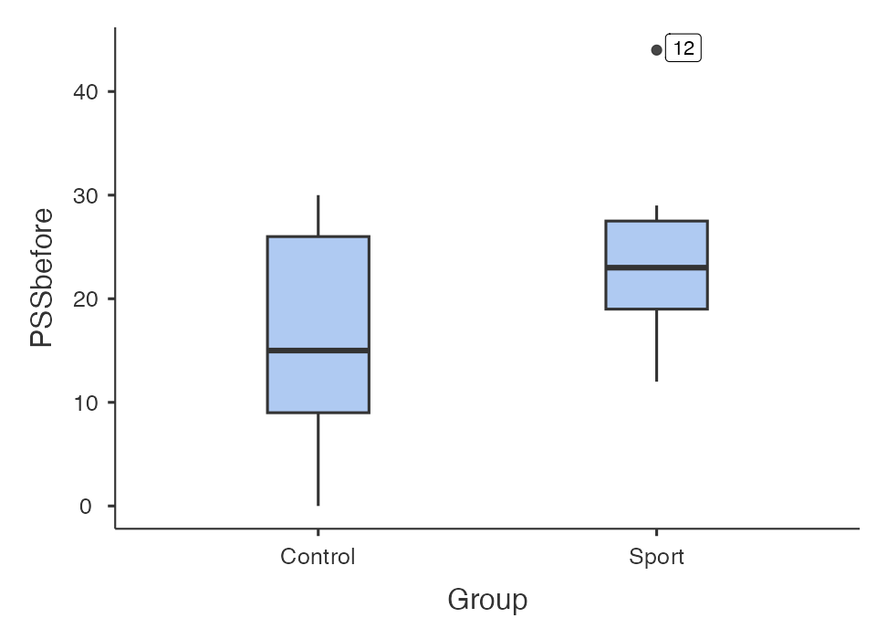

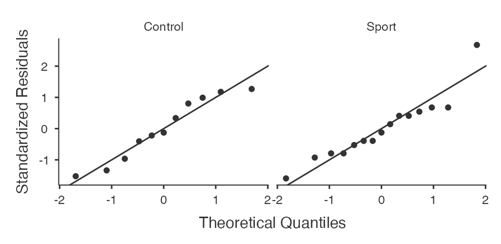

Die Prüfung der Testbedingungen legt nichtparametrische Verfahren zur statistischen Analyse nahe: Stichprobenumfänge < 30 sowie unterschiedlich grosse Stichprobenumfänge.

7. Vertrauensintervalle für die Prüfgrösse und Teststatistik bestimmen

**jamovi** > Register *Analyses* > *T-Tests* > *Independent Samples T-Test* > Dependent Variables: `PSSbefore`, Grouping Variable: `Group`, Häkchen bei Test: *Mann-Whitney-U*, Häckchen bei Additional Statistics: *Mean Difference*, *Confidence interval*

Independent Samples T-Test

| Independent Samples T-Test | Independent Samples T-Test | Independent Samples T-Test Statistic | Independent Samples T-Test p | Independent Samples T-Test Mean difference | Independent Samples T-Test SE difference | Independent Samples T-Test 95% Confidence Interval Lower | Independent Samples T-Test 95% Confidence Interval Upper |
| --- | --- | --- | --- | --- | --- | --- | --- |
| PSSbefore | Mann-Whitney U | 52.50 | .123 | -7.000 |  | -15.00 | 2.000 |
| *Note.* Hₐ μ <sub>Control</sub> ≠ μ <sub>Sport</sub> |  |  |  |  |  |  |  |

**Lösung 2**

Fragestellung: Haben beide Gruppen bei Austritt den gleichen Stresslevel?

1. Hypothesen
   - $H_0$ Es besteht kein Unterschied im Stresslevel der Gruppen Sport und Kontrolle bei Austritt, $\mu_{con,after} = \mu_{sport,after}$
   - $H_A$ Es besteht ein Unterschied im Stresslevel der Gruppen Sport und Kontrolle bei Austritt, $\mu_{con,after} \neq \mu_{sport,after}$
2. Das Signifikanzniveau legen wir bei $\alpha = .05$ fest.
3. Die Daten sind unabhängig.
4. Die Prüfgrösse ist $\mu_{con,after} - \mu_{sport,after}$.
5. Der Stichprobenumfang pro Gruppe ist n < 30, was für Man-Whitney-U-Test spricht.
6. Die Verteilung der Prüfgrösse anhand der Box im Boxplot ergibt eine leicht rechtssteile Verteilung in beiden Gruppen. Die QQ-Plots sind wenig aussagekräftig. Die Streuung der Daten ist ähnlich.

Descriptives

| Descriptives | Descriptives Group | Descriptives PSSafter |
| --- | --- | --- |
| N | Control | 11 |
|  | Sport | 15 |
| Missing | Control | 0 |
|  | Sport | 0 |
| Mean | Control | 23.73 |
|  | Sport | 20.00 |
| Median | Control | 26.00 |
|  | Sport | 21.00 |
| Standard deviation | Control | 7.115 |
|  | Sport | 6.908 |
| Minimum | Control | 9.000 |
|  | Sport | 8.000 |
| Maximum | Control | 33.00 |
|  | Sport | 33.00 |

Plots

PSSafter

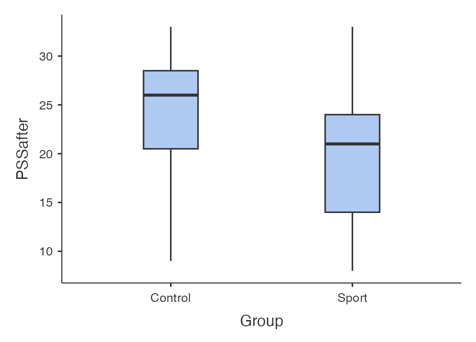

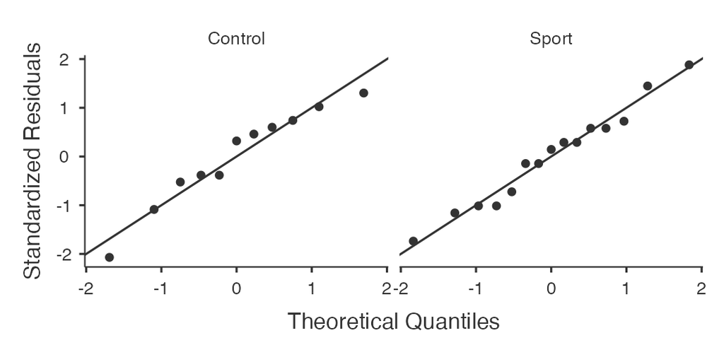

Die Prüfung der Testbedingungen (n < 30, rechtssteile Verteilungen, unterschiedliche Stichprobenumfänge) legt nichtparametrische Verfahren zur statistischen Analyse nahe.

Independent Samples T-Test

| Independent Samples T-Test | Independent Samples T-Test | Independent Samples T-Test Statistic | Independent Samples T-Test p | Independent Samples T-Test Mean difference | Independent Samples T-Test SE difference | Independent Samples T-Test 95% Confidence Interval Lower | Independent Samples T-Test 95% Confidence Interval Upper |
| --- | --- | --- | --- | --- | --- | --- | --- |
| PSSafter | Mann-Whitney U | 56.50 | .184 | 4.000 |  | -3.000 | 9.000 |
| *Note.* Hₐ μ <sub>Control</sub> ≠ μ <sub>Sport</sub> |  |  |  |  |  |  |  |

8. Schlussfolgerung

*Der Stresslevel bei aus dem Gefängnis ist in der Kontrollgruppe (n = 11) im Durchschnitt (Median) um 4.0 [-3.0; 9.0] Punkte höher als in der Sportgruppe (n = 15). Es liegt jedoch keine Evidenz dafür vor, dass sich die beiden Gruppen im Stresslevel bei Austritt aus dem Gefängnis signifikant unterscheiden, Man-Whitney-U = 56.5, p = 0.185.*

**Lösung 3**

Fragestellung: Besteht ein Unterschied im Stresslevel zwischen Ein- und Austritt in der Kontrollgruppe?

Tipp: Erstellen Sie in jamovi einen Filter `= Group == Control`.

1. Hypothesen
   - $H_0:$ Es besteht kein Unterschied im Stresslevel in der Kontrollgruppe zwischen Ein- und Austritt, $\mu_{con,diff} = 0$ (Mittelwert der paarweisen Differenzen!)
   - $H_A:$ Es besteht ein Unterschied im Stresslevel in der Kontrollgruppe bei Eintritt, $\mu_{con,diff} \neq 0$
2. Das Signifikanzniveau legen wir bei $\alpha = .05$ fest.
3. Die Daten sind gepaart (2 Messungen pro Proband:in)
4. Die Prüfgrösse ist $\mu_{con,diff}$ . Die paarweisen Differenzen sind im Datensatz in der Variablen `Diff` abgelegt.
5. Der Stichprobenumfang pro Gruppe ist n < 30, was für den Wilcoxon-Vorzeichenrang-Test spricht.
6. Die Verteilung der Prüfgrösse `Diff` anhand von Boxplot und QQ-Plot ist auf Grund der geringen Datenmenge wenig zuverlässig zu interpretieren; es scheint aber nichts dagegen zu sprechen, dass die Daten aus einer normalverteilten Population stammen.

Descriptives

| Descriptives | Descriptives Diff |
| --- | --- |
| N | 11 |
| Missing | 0 |
| Mean | 7.364 |
| Median | 7.000 |
| Standard deviation | 9.233 |
| Minimum | -8.000 |
| Maximum | 20.00 |

Plots

Diff

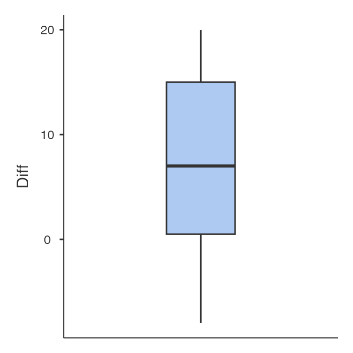

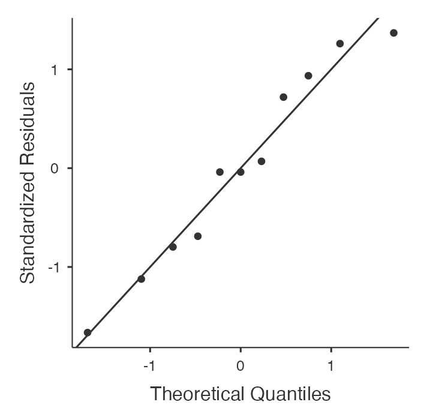

Die paarweisen Differenzen scheinen im QQ-Plot normalverteilt zu sein. Die Prüfung der weiteren Testbedingungen (n < 30) legt jedoch nichtparametrische Verfahren zur statistischen Analyse nahe. Wir führen aber übungshalber auch den *t-Test für gepaarte Daten* durch

7. Vertrauensintervalle für die Prüfgrösse und Teststatistik bestimmen

**jamovi** > Register *Analyses* > *T-Tests* > *Paired Samples T-Test* > Paired Variables: `PSSafter`, `PSSbefore` (Achtung: Reihenfolge beachten, `PSSafter` sollte links, `PSSafter` sollte rechts im Paired-Variables-Fenster stehen) > Tests: Häkchen bei *Student’s t* und *Wilcoxon rank* setzen > Additional Statistics: Häkchen bei *Mean difference* und *Confidence Interval* setzen.

Als Alternative können Sie auch einen Einstichproben-t-Test für die Variable `Diff` durchführen: **jamovi** > Register *Analyses* > *T-Tests* > *One Sample T-Test* > Dependent Variables: `Diff` > Tests: *Student’s*, *Wilcoxon rank* > Hypothesis: *Test value* = 0 > Additional Statistics: Häkchen bei *Mean difference* und *Confidence Interval* setzen.

- Wilcoxon rank-Test: V = 47.5, p = .0466
- Paired Samples T-Test: t = 2.645, df = 10, p = .0245
- Wilcoxon rank: Das 95% Vertrauensintervall für $Md_{con,diff}$ beinhaltet den Nullwert knapp nicht: 8.0 [0.00003; 16]
- Student’s t-Test: Das 95% Vertrauensintervall für $\mu_{con,diff}$ beinhaltet den Nullwert nicht: 7.4 [1.2; 13.6]

Paired Samples T-Test

| Paired Samples T-Test | Paired Samples T-Test | Paired Samples T-Test | Paired Samples T-Test statistic | Paired Samples T-Test df | Paired Samples T-Test p | Paired Samples T-Test Mean difference | Paired Samples T-Test SE difference | Paired Samples T-Test 95% Confidence Interval Lower | Paired Samples T-Test 95% Confidence Interval Upper |
| --- | --- | --- | --- | --- | --- | --- | --- | --- | --- |
| PSSafter | PSSbefore | Student's t | 2.645 | 10.00 | .025 | 7.364 | 2.784 | 1.161 | 13.57 |
|  |  | Wilcoxon W | 47.50<sup>a</sup> |  | .047 | 8.000 | 2.784 | 2.612e-5 | 16.00 |
| *Note.* Hₐ μ <sub>Measure 1 - Measure 2</sub> ≠ 0 |  |  |  |  |  |  |  |  |  |
| <sup>a</sup> 1 pair(s) of values were tied |  |  |  |  |  |  |  |  |  |

8. Schlussfolgerung

*Der Stresslevel bei Austritt aus dem Gefängnis ist in der Kontrollgruppe (n = 11) im Durchschnitt (Median) um 8 Punkte [0.00003; 16.0] höher als beim Eintritt. Es liegt Evidenz dafür vor, dass sich der Stresslevel bei Austritt aus dem Gefängnis signifikant gegenüber dem Stresslevel bei Eintritt erhöht, Wilcoxon Vorzeichenrang-Test V = 47.5, p = 0.047.*

**Lösung 4**

Fragestellung: Besteht ein Unterschied im Stresslevel zwischen Ein- und Austritt in der Sportgruppe?

Tipp: Deaktivieren Sie den Filter `= Group == "Control"` und erstellen Sie einen Filter `= Group == Sport`.

1. Hypothesen
   - $H_0$ Es besteht kein Unterschied im Stresslevel in der Sportgruppe zwischen Ein- und Austritt, $\mu_{sport,diff} = 0$ (Mittelwert der paarweisen Differenzen!)
   - $H_A$ Es besteht ein Unterschied im Stresslevel in der Kontrollgruppe bei Eintritt, $\mu_{sport,diff} \neq 0$$
2. Das Signifikanzniveau legen wir bei $\alpha = .05$ fest.
3. Die Daten sind gepaart (2 Messungen pro Proband)
4. Die Prüfgrösse ist $\mu_{sport,diff}$
5. Der Stichprobenumfang pro Gruppe ist n < 30, was für Wilcoxon-Vorzeichenrang-Test spricht.
6. Die Verteilung der Prüfgrösse `Diff` anhand von Boxplot und QQ-Plot ist auf Grund der geringen Datenmenge wenig zuverlässig zu interpretieren.

Descriptives

| Descriptives | Descriptives Diff |
| --- | --- |
| N | 15 |
| Missing | 0 |
| Mean | -3.933 |
| Median | -4.000 |
| Standard deviation | 5.675 |
| Minimum | -15.00 |
| Maximum | 4.000 |

Plots

Diff

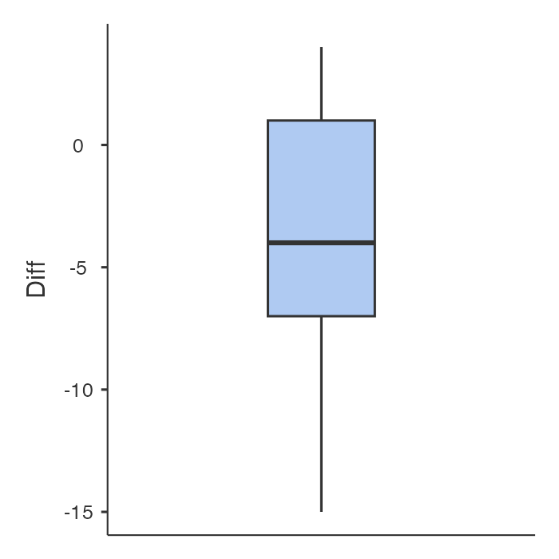

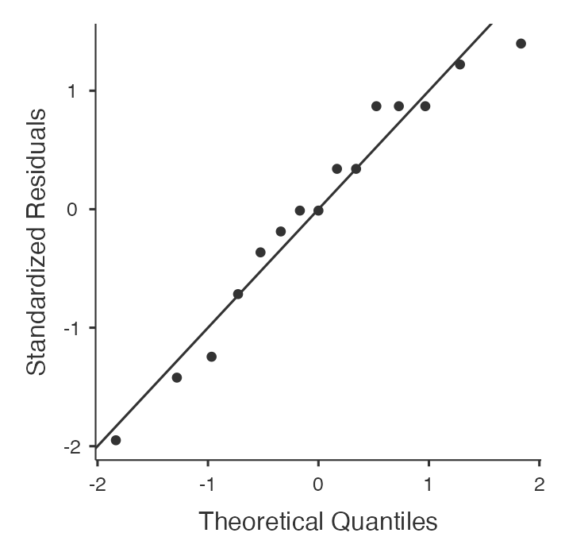

Die Prüfung der Testbedingungen legt nichtparametrische Verfahren zur statistischen Analyse nahe: asymmetrischer Boxplot, QQ-Plot unsicher zu beurteilen.

7. Vertrauensintervalle für die Prüfgrösse und Teststatistik bestimmen

Achtung: Filter muss `= Group == Sport` sein. Alle anderen Filter müssen deaktiviert sein.

**jamovi** > Register *Analyses* > *T-Tests* > *Paired Samples T-Test* > Paired Variables: `PSSafter`, `PSSbefore` (Achtung: Reihenfolge beachten, `PSSafter` sollte links, `PSSafter` sollte rechts im Paired-Variables-Fenster stehen) > Tests: Häkchen bei *Student’s t* und *Wilcoxon rank* setzen > Additional Statistics: Häkchen bei *Mean difference* und *Confidence Interval* setzen.

Als Alternative können Sie auch einen Einstichproben-t-Test für die Variable `Diff` durchführen: **jamovi** > Register *Analyses* > *T-Tests* > *One Sample T-Test* > Dependent Variables: `Diff` > Tests: *Student’s*, *Wilcoxon rank* > Hypothesis: Hypothesis: *Test value* = 0 > Additional Statistics: Häkchen bei *Mean difference* und *Confidence Interval* setzen.

- Wilcoxon Vorzeichenrang-Test: W = 20, p = .0246
- Paired Samples t-Test: t = -2.6842, df = 14, p = .0178
- Das 95% Vertrauensintervall für $Md_{sport,diff}$ beinhaltet den Nullwert nicht: -3.6 [-7.0, -0.5.0].
- Das 95% Vertrauensintervall für $\mu_{sport,diff}$ beinhaltet den Nullwert nicht: -3.9 [-7.08, -0.790].

Paired Samples T-Test

| Paired Samples T-Test | Paired Samples T-Test | Paired Samples T-Test | Paired Samples T-Test statistic | Paired Samples T-Test df | Paired Samples T-Test p | Paired Samples T-Test Mean difference | Paired Samples T-Test SE difference | Paired Samples T-Test 95% Confidence Interval Lower | Paired Samples T-Test 95% Confidence Interval Upper |
| --- | --- | --- | --- | --- | --- | --- | --- | --- | --- |
| PSSafter | PSSbefore | Student's t | -2.684 | 14.00 | .018 | -3.933 | 1.465 | -7.076 | -0.7904 |
|  |  | Wilcoxon W | 20.00 |  | .025 | -3.579 | 1.465 | -7.000 | -0.5000 |
| *Note.* Hₐ μ <sub>Measure 1 - Measure 2</sub> ≠ 0 |  |  |  |  |  |  |  |  |  |

8. Schlussfolgerung

*Der Stresslevel bei Austritt aus dem Gefängnis ist in der Sportgruppe (n = 15) im Durchschnitt (Median) um 3.6 Punkte [-7.0; -0.5] tiefer als beim Eintritt. Es liegt Evidenz dafür vor, dass sich der Stresslevel bei Austritt aus dem Gefängnis in der Sportgruppe gegenüber dem Stresslevel bie Eintritt signifikant senkt, Wilcoxon Vorzeichenrang-Test W = 20, p = 0.0246.*

**Lösung 5**

Fragestellung: Hat Sport einen Effekt auf den Stresslevel im Vergleich zu einer Kontrollgruppe, die keinen Sport macht?

Wir vergleichen in dieser Frage den Effekt `Diff` in den beiden Gruppen `Sport` und `Control`. Zur Analyse dieser Frage müssen alle Filter in **jamovi** deaktiviert werden!

1. Hypothesen
   - $H_0$ Sport hat keinen Effekt, $\mu_{diff,sport} = \mu_{diff,con}$
   - $H_A$ Sport hat einen Effekt, $\mu_{diff,sport} \neq \mu_{diff,con}$
2. Das Signifikanzniveau legen wir bei $\alpha = .05$ fest.
3. Die Daten sind unabhängig.
4. Die Prüfgrösse ist $\mu_{diff,sport} = \mu_{diff,con}$
5. Der Stichprobenumfang pro Gruppe ist n < 30, was für Mann-Whitney-U-Test spricht.
6. Die Verteilung der Daten in beiden Gruppen anhand von Boxplot und QQ-Plot ist auf Grund der geringen Datenmenge wenig zuverlässig zu interpretieren; es scheint aber nichts dagegen zu sprechen, dass die Daten aus einer normalverteilten Population stammen.

Descriptives

| Descriptives | Descriptives Group | Descriptives Diff |
| --- | --- | --- |
| N | Control | 11 |
|  | Sport | 15 |
| Missing | Control | 0 |
|  | Sport | 0 |
| Mean | Control | 7.364 |
|  | Sport | -3.933 |
| Median | Control | 7.000 |
|  | Sport | -4.000 |
| Standard deviation | Control | 9.233 |
|  | Sport | 5.675 |
| Minimum | Control | -8.000 |
|  | Sport | -15.00 |
| Maximum | Control | 20.00 |
|  | Sport | 4.000 |

Plots

Diff

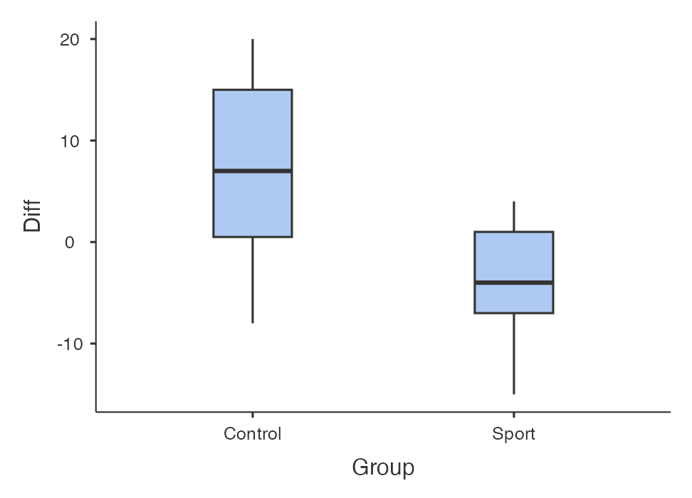

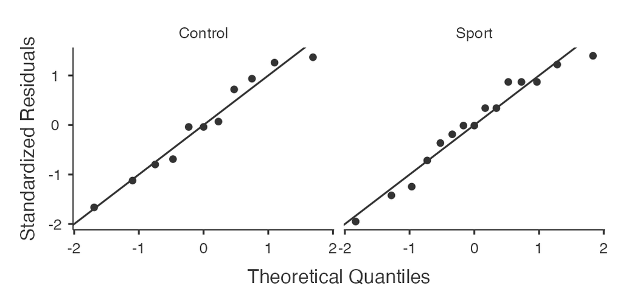

- Der Stresslevel hat zwischen Ein- und Austritt in der Kontrollgruppe im durchschnitt um 7.4 Punkte zugenommen und in der Sportgruppe um durchschnittlich -3.9 Punkte abgenommen!
- Die Prüfung der Testbedingungen (n < 30, unterschiedliche Stichprobenumfänge) legt nichtparametrische Verfahren zur statistischen Analyse nahe.
7. Vertrauensintervalle für die Prüfgrösse und Teststatistik bestimmen

**jamovi** > Register *Analyses* > *T-Tests* > *Independent Samples T-Test* > Dependent Variables: `Diff`, Grouping Variable: `Group`, Häkchen bei Test: *Mann-Whitney-U*, Häckchen bei Additional Statistics: *Mean Difference*, *Confidence interval*

Independent Samples T-Test

| Independent Samples T-Test | Independent Samples T-Test | Independent Samples T-Test Statistic | Independent Samples T-Test p | Independent Samples T-Test Mean difference | Independent Samples T-Test SE difference | Independent Samples T-Test 95% Confidence Interval Lower | Independent Samples T-Test 95% Confidence Interval Upper |
| --- | --- | --- | --- | --- | --- | --- | --- |
| Diff | Mann-Whitney U | 27.00 | .003 | 12.00 |  | 4.000 | 18.00 |
| *Note.* Hₐ μ <sub>Control</sub> ≠ μ <sub>Sport</sub> |  |  |  |  |  |  |  |

8. Schlussfolgerung

# Aufgabe 5

Unterscheidet sich der BMI von weiblichen und männlichen Physiotherapie-Studierenden?

Wir prüfen diese Frage anhand zweier Zufallsstichproben von 45 männlichen und 45 weiblichen Physiotherapie-Studierenden. Laden Sie den Datensatz bmi_phy_45.csv in **jamovi**.

**Hinweis:** Dies ist die Aufgabe welche zur Einführung vom Vergleich von unabhängigen Stichproben weiter oben verwendet wurde.

**Aufgabe**

Führen Sie eine inferenzstatistische Analyse zur Fragestellung durch, ob sich der BMI von weiblichen und männlichen Studierenden unterscheidet. Legen Sie das Signifikanzniveau auf $\alpha$ = .05 fest.

Codebook: Der Datensatz `bmi_phy_45.csv` umfasst zwei Variablen. Die Skalenniveaus werden von **jamovi** automatisch richtig erkannt.

| Variable | Beschreibung | jamovi Skalenniveau |
| --- | --- | --- |
| Geschlecht | m = männlich, w = weiblich | nominal-text |
| bmi | Body Mass Index, $kg/m^2$ | continuous-decimal |

**Lösung**

1. Deskriptive Zusammenfassung (Kennzahlen)

Es wird empfohlen, stets die wichtigsten Kennzahlen zu berechnen.

**jamovi** > Register *Analyses* > *Exploration* > *Descriptives* > `bmi` in *Variables* einfügen, `Geschlecht` in *Split by* einfügen. Gewünschte Kennzahlen unter *Statistics* auswählen.

Descriptives

| Descriptives | Descriptives Geschlecht | Descriptives bmi |
| --- | --- | --- |
| N | m | 45 |
|  | w | 45 |
| Missing | m | 0 |
|  | w | 0 |
| Mean | m | 22.52 |
|  | w | 20.98 |
| Median | m | 22.41 |
|  | w | 20.94 |
| Standard deviation | m | 2.235 |
|  | w | 1.818 |
| Minimum | m | 16.91 |
|  | w | 17.18 |
| Maximum | m | 27.78 |
|  | w | 24.54 |

- Die Stichprobenumfänge betragen je 45 Studierende pro Geschlecht.
- Der durchschnittliche BMI von Studentinnen beträgt ca. 21.0 $kg/m^2$ und von Studenten ca. 22.5 $kg/m^2$.
2. Statistische Hypothesen formulieren
   - $H_0: \mu_w = \mu_m$
   - $H_A: \mu_w \neq \mu_m$
3. Signifkanzniveau festlegen
- $\alpha$ = .05
4. Sind die Daten gepaart oder unabhängig?

Es besteht kein Zusammenhang zwischen dem BMI von Studenten und von Studentinnen. Es handelt sich um nicht gepaarte (unabhängige) Stichproben.

5. Prüfgrösse bestimmen

Die Prüfgrösse ist die Differenz der Mittelwerte: $\mu_m - \mu_w$

6. Voraussetzungen prüfen
- Es handelt sich um Zufallsstichproben. Es kann davon ausgegangen werden, dass die Beobachtungseinheiten unabhängig voneinander sind.
- Der Stichprobenumfang pro Gruppe ist grösser als 30.
- Normalverteilung für beide Stichproben mittels QQ-Plot prüfen

**jamovi** > Register *Analyses* > *Exploration* > `bmi` in *Variables* einfügen, `Geschlecht` in *Split by* einfügen. Unter *Plots* > Q-Q Plots > Häkchen bei *Q-Q*.

Descriptives

| Descriptives | Descriptives Geschlecht | Descriptives bmi |
| --- | --- | --- |
| N | m | 45 |
|  | w | 45 |
| Missing | m | 0 |
|  | w | 0 |
| Mean | m | 22.52 |
|  | w | 20.98 |
| Median | m | 22.41 |
|  | w | 20.94 |
| Standard deviation | m | 2.235 |
|  | w | 1.818 |
| Minimum | m | 16.91 |
|  | w | 17.18 |
| Maximum | m | 27.78 |
|  | w | 24.54 |

Plots

bmi

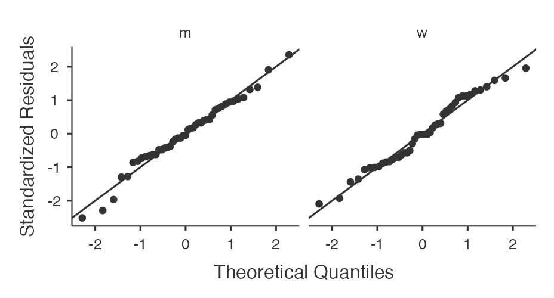

In beiden Stichproben sind die Daten annähernd normalverteilt.

7. 95%-Konfidenzintervalle für die Populationsmittelwerte beider Gruppen berechnen

**jamovi** > Register *Analyses* > *Exploration* > *Descriptives* > *Mean Dispersion* > bei *Confidence interval for Mean* ein Häkchen setzen, Vorgabe ist der Wert 95 für ein 95%-CI.

Descriptives

| Descriptives | Descriptives Geschlecht | Descriptives bmi |
| --- | --- | --- |
| N | m | 45 |
|  | w | 45 |
| Missing | m | 0 |
|  | w | 0 |
| Mean | m | 22.52 |
|  | w | 20.98 |
| 95% CI mean lower bound | m | 21.85 |
|  | w | 20.44 |
| 95% CI mean upper bound | m | 23.19 |
|  | w | 21.53 |
| Median | m | 22.41 |
|  | w | 20.94 |
| Standard deviation | m | 2.235 |
|  | w | 1.818 |
| Minimum | m | 16.91 |
|  | w | 17.18 |
| Maximum | m | 27.78 |
|  | w | 24.54 |
| *Note.* The CI of the mean assumes sample means follow a t-distribution with N - 1 degrees of freedom |  |  |

- Leider liefert der Output hier nicht das korrekte Resultat (das jamovi-Package für den verwendeten Editor ist veraltet). Korrekt sind:
  - 95% CI mean lower bound: m = 21.8504, w = 20.4377
  - 95% CI mean upper bound: m = 23.1933, w = 21.5302
- *Physiotherapie-Studentinnen haben einen durchschnittlichen BMI von 20.984 [20.438, 21.530] $kg/m^2$ und Physiotherapie-Studenten haben einen durchschnittlichen BMI von 22.522 [21.850, 23.193] $kg/m^2$. Männer haben im Durchschnitt einen um 1.538 [0.684, 2.392] $kg/m^2$ signifikant höheren BMI als Frauen. Dieses 95%-Konfidenzintervall enthält den Nullwert nicht und wir haben Evidenz gegen die Nullhypothese.*
8. Teststatistik und p-Wert berechnen
- **jamovi** > Register *Analyses* > *T-Tests* > *Independent Samples T-Test > Tests:* > *Welch’s* und unter > Hypothesis *Group 1 $\neq$ Group 2* wählen. Für das 95%-CI der Differenz zwischen den beiden Gruppen unter > *Additional Statistics* > *Mean difference* und *Confidence interval* wählen.
- Für die grafische Anzeige der 95%-Konfidenzintervalle kann unter *Additional Statistics* > *Descriptive Plots* gewählt werden.

Independent Samples T-Test

| Independent Samples T-Test | Independent Samples T-Test | Independent Samples T-Test Statistic | Independent Samples T-Test df | Independent Samples T-Test p | Independent Samples T-Test Mean difference | Independent Samples T-Test SE difference | Independent Samples T-Test 95% Confidence Interval Lower | Independent Samples T-Test 95% Confidence Interval Upper |
| --- | --- | --- | --- | --- | --- | --- | --- | --- |
| bmi | Welch's t | 3.581 | 84.50 | < .001 | 1.538 | 0.4295 | 0.6839 | 2.392 |
| *Note.* Hₐ μ <sub>m</sub> ≠ μ <sub>w</sub> |  |  |  |  |  |  |  |  |

Plots

bmi

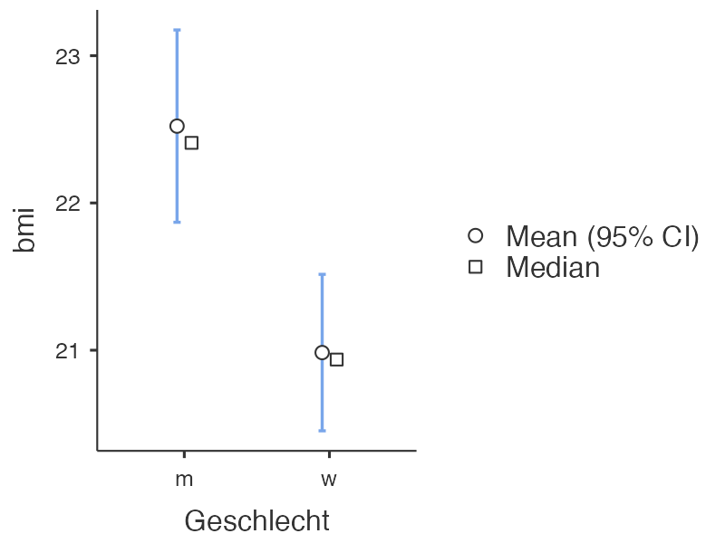

# Aufgabe 6

In einer Studie wird der Effekt eines neuen Schlafmittels untersucht. Die Studie wird mit 20 Testpersonen durchgeführt. Zuerst wird die Schlafdauer ohne Medikament, dann die Schlafdauer mit Medikament gemessen.

Laden Sie den Datensatz schlafmittel.csv in **jamovi**.

Codebook: Der Datensatz umfasst drei Variablen:

| Variable | Beschreibung | jamovi Skalenniveau |
| --- | --- | --- |
| Proband | Proband:innen-ID | nominal-text |
| ohne_Med | Schlafdauer ohne Medikament, h | continuous-decimal |
| mit_Med | Schlafdauer mit Medikament, h | continuous-decimal |

*Hinweis:* Dies ist die gleiche Fragestellung welche weiter oben zur Einführung des Vergleichs von abhängigen Stichproben verwendet wurde.

**Aufgabe**

Hat das neue Schlafmittel einen Effekt auf die Schlafdauer? Führen Sie eine inferenzstatistische Analyse zu dieser Fragestellung durch. Legen Sie das Signifikanzniveau auf $\alpha$ = .05 fest.

**Lösung**

1. Datensatz einlesen und Struktur analysieren
- Der Datensatz umfasst drei Variablen `Proband`, `ohne_Med` und `mit_Med` von 20 Proband:innen.
2. Deskriptive Zusammenfassung (Kennzahlen)

Descriptives

| Descriptives | Descriptives ohne_Med | Descriptives mit_Med |
| --- | --- | --- |
| N | 20 | 20 |
| Missing | 0 | 0 |
| Mean | 5.376 | 5.771 |
| Median | 5.260 | 5.645 |
| Standard deviation | 0.5743 | 0.9528 |
| Minimum | 4.340 | 4.340 |
| Maximum | 6.500 | 8.080 |

3. Statistische Hypothesen
- $H_0: \mu_{diff} = 0$
- $H_A: \mu_{diff} \neq 0$
4. Sind die Daten gepaart oder unabhängig?
- Es handelt sich um zwei Messungen an den gleichen Probanden: Schlafdauer einmal ohne und einmal mit dem neuen Medikament. In diesem Fall besteht ein Zusammenhang zwischen der ersten und der zweiten Messung, d.h. die Daten sind gepaart.
- Der Zusammenhang zwischen den Messungen kann in einem Streudiagramm (engl. scatterplot) dargestellt werden.
- **jamovi** > Register *Analyses* > *Exploration* > *Scatterplot* > `ohne_Med` als X-Axis, `mit_Med` als Y-Axis.

Scatterplot

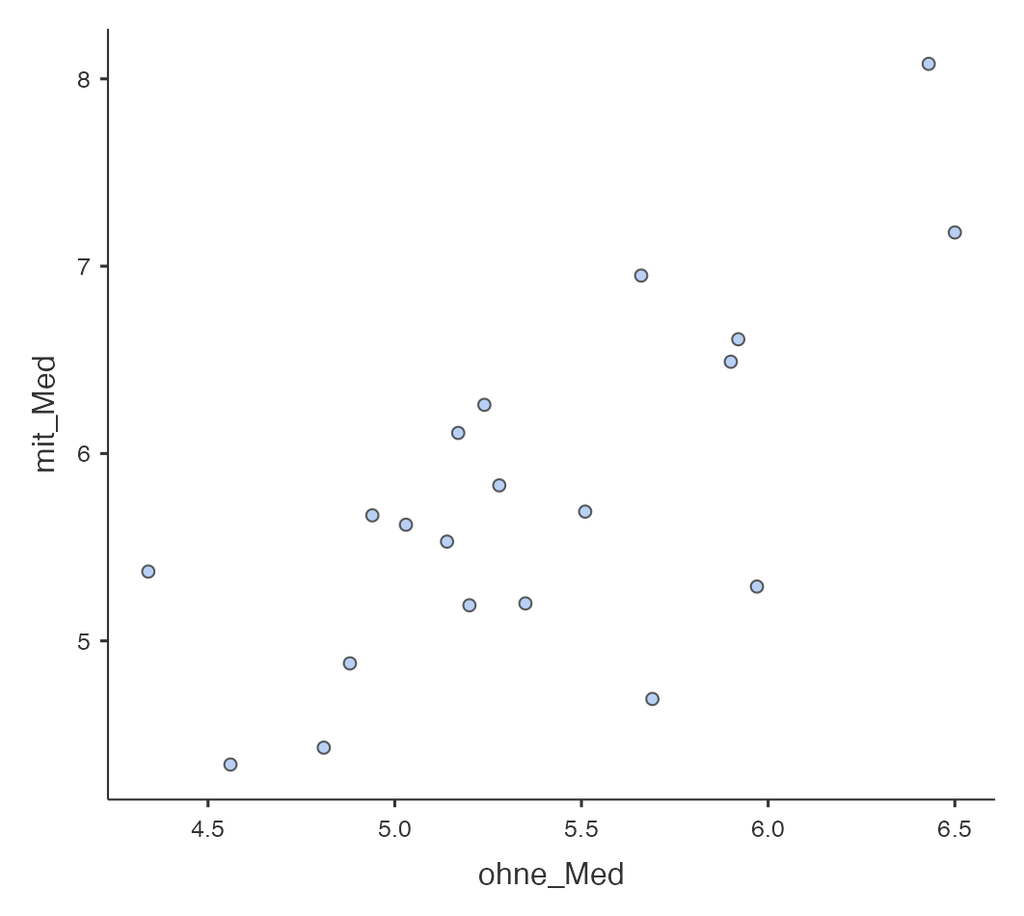

- Das Streudiagramm zeigt in der Tendenz, dass Testpersonen, die ohne Medikament länger schlafen auch mit Medikament länger schlafen. Es besteht ein postiver Zusammenhang zwischen der Schlafdauer ohne und mit Medikament (siehe auch unter Korrelation).
5. Prüfgrösse
- Die Prüfgrösse bei gepaarten Daten ist der Mittelwert der paarweisen Differenzen $\mu_{diff}$
- Die paarweisen Differenzen müssen als neue Variable berechnet werden.

**jamovi** > Register *Data* > *Compute* > Variablennamen eingeben, z.B. `diff` > im Formelfenster `= mit_Med - ohne_Med` eintragen.

Descriptives

| Descriptives | Descriptives ohne_Med | Descriptives mit_Med | Descriptives diff |
| --- | --- | --- | --- |
| N | 20 | 20 | 20 |
| Missing | 0 | 0 | 0 |
| Mean | 5.376 | 5.771 | 0.3945 |
| Median | 5.260 | 5.645 | 0.5700 |
| Standard deviation | 0.5743 | 0.9528 | 0.6724 |
| Minimum | 4.340 | 4.340 | -1.000 |
| Maximum | 6.500 | 8.080 | 1.650 |

6. Voraussetzungen prüfen
- Es handelt sich um eine Zufallsstichprobe und wir können davon ausgehen, dass die Beobachtungseinheiten voneinander unabhängig sind.
- Der Stichprobenumfang ist grösser als 12; ein parametrischer Test ist möglich.
- Ist die Prüfgrösse normalverteilt?
- **jamovi** > Register *Analyses* > *Exploration* > `diff` in *Variables* auswählen > *Plots* > *Q-Q Plots* > Häkchen bei *Q-Q* setzen.

Descriptives

| Descriptives | Descriptives diff |
| --- | --- |
| N | 20 |
| Missing | 0 |
| Mean | 0.3945 |
| Median | 0.5700 |
| Standard deviation | 0.6724 |
| Minimum | -1.000 |
| Maximum | 1.650 |

Plots

diff

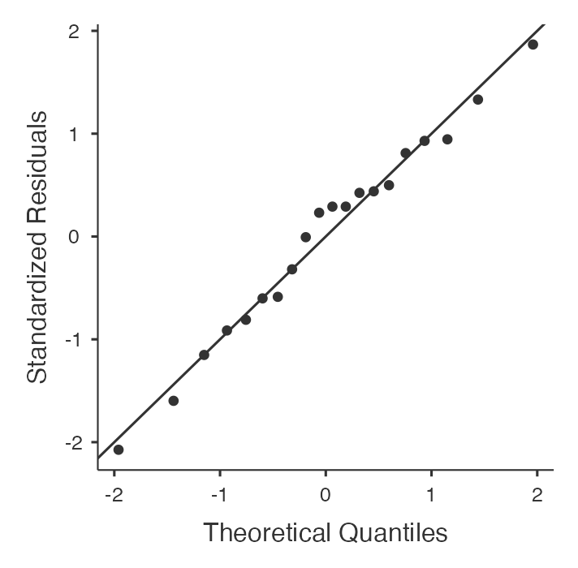

- Der QQ-Plot liefert keine Evidenz gegen die Annahme, dass die paarweisen Differenzen normalverteilt sind.
7. 95%-Konfidenzintervall für $\hat{\mu}_{diff}$ berechnen
- **jamovi** > Register *Analyses* > *Descriptives* > `diff` als Variable auswählen > *Statistics* > *Mean Dispersion*: Häkchen bei *Confidence Interval for Mean* setzen.

Descriptives

| Descriptives | Descriptives diff |
| --- | --- |
| N | 20 |
| Missing | 0 |
| Mean | 0.3945 |
| 95% CI mean lower bound | 0.07979 |
| 95% CI mean upper bound | 0.7092 |
| Median | 0.5700 |
| Standard deviation | 0.6724 |
| Minimum | -1.000 |
| Maximum | 1.650 |
| *Note.* The CI of the mean assumes sample means follow a t-distribution with N - 1 degrees of freedom |  |

- Leider liefert der Output hier nicht das korrekte Resultat (das jamovi-Package für den verwendeten Editor ist veraltet). Korrekt sind:
  - 95% CI mean lower bound: 0.0798
  - 95% CI mean upper bound: 0.7092
- *Die Einnahme des Schlafmittels verlängert den Schlaf im Durchschnitt um 0.395 [0.080, 0.709] Stunden. Das 95%-Konfidenzintervall beinhaltet den Nullwert nicht und wir haben Evidenz gegen die Nullhypothese, bzw. Evidenz für einen signifikanten Effekt des Medikaments auf die Schlafdauer.*
8. Teststatistik und $p$-Wert berechnen

Die Berechnung der Teststatistik $t$ und des $p$-Werts kann auf zweierlei Arten erfolgen:

- Variante 1: Als $t$-Test für verbundene Stichproben oder
- Variante 2: Als Einstichproben-$t$-Test mit der Variablen `diff` und dem Referenzwert 0 (siehe Hypothesen oben)
- Variante 1: **jamovi** > Register *Analyses* > *T-Tests* > *Paired Samples T-Test* > 1. `mit_Med`, 2. `ohne_Med` als *Paired Variables* einsetzen (Achtung: Reihenfolge beachten)> *Tests* > *Student’s* wählen; unter > Additional Statistics: Häkchen bei *Mean difference* und *Confidence Interval* setzen.
- Variante 2: **jamovi** > Register *Analyses* > *T-Tests* > *One Sample T-Test* > `diff` in *Dependent Variables* einsetzen > Tests: *Student’s* wählen, unter > *Additional Statistics* Häkchen bei *Mean difference* und *Confidence Interval* setzen.

One Sample T-Test

| One Sample T-Test | One Sample T-Test | One Sample T-Test Statistic | One Sample T-Test df | One Sample T-Test p | One Sample T-Test Mean difference | One Sample T-Test 95% Confidence Interval Lower | One Sample T-Test 95% Confidence Interval Upper |
| --- | --- | --- | --- | --- | --- | --- | --- |
| diff | Student's t | 2.624 | 19.00 | .017 | 0.3945 | 0.07979 | 0.7092 |
| *Note.* Hₐ μ ≠ 0 |  |  |  |  |  |  |  |

9. Schlussfolgerung
- *Geprüft wurde die Frage, ob ein neues Schlafmittel einen Effekt auf die Schlafdauer hat. Die Studie mit 20 Testpersonen ergab, das die Einnahme des Schlafmittels den Schlaf im Durchschnitt signifikant um 0.395 [0.080, 0.709] Stunden verlängert, $t$ = 2.624, $df$ = 19, $p$ = .017.*
- Diskussion: Wir ermitteln eine durchsnittliche Verlängerung der Schlafdauer um 0.395 Stunden. 0.395 Stunden entsprechen 23.7 Minuten. Ob die Verlängerug der Schlafdauer um 23.7 Minuten klinisch relevant ist, d.h. für Menschen mit Schlafstörungen einen subjektiv bemerkbaren Effekt hat, müsste an anderer Stelle geklärt werden.